```r
documento <- read.csv("C:/Users/lucas.general/Documents/Documentos R Markdown/CRM/Segmentos/Push/Push_Segmentos.csv", encoding = "UTF-8")
clientes <- read.csv("C:/Users/lucas.general/Documents/Documentos R Markdown/CRM/Segmentos/Push/Clientes.csv", encoding = "UTF-8")

aberturas <- read.csv("C:/Users/lucas.general/Documents/Documentos R Markdown/CRM/Segmentos/Push/aberturas.csv", encoding = "UTF-8")
mensagens <- read.csv("C:/Users/lucas.general/Documents/Documentos R Markdown/CRM/Segmentos/Push/Push_Segementos2.csv", encoding = "UTF-8")


aberturas <- aberturas %>%
  rename(segment = X.U.FEFF.segment)

documento <- documento %>%
  rename(fk_customer = X.U.FEFF.fk_customer)

mensagens <- mensagens %>%
  rename(pk_customer = X.U.FEFF.pk_customer)

clientes <- clientes %>%
  rename(fk_customer = X.U.FEFF.fk_customer)

clientes <- clientes %>%
  filter(grupo != '')

principais_mensagens <-
  documento %>%
      group_by(message) %>%
      summarise(contagem = n()) %>%
      arrange(desc(contagem)) %>%
      head(10)
```

```r
freq_semAbertura <- read.csv("C:/Users/lucas.general/Documents/Documentos R Markdown/CRM/Segmentos/Push/Frequencia_ClientesSemAbertura.csv", encoding = "UTF-8")

freq_semAbertura <- freq_semAbertura %>%
  rename(pk_customer = X.U.FEFF.pk_customer)
```

# Analise Segmentos

Clientes cadastrados entre 06/2020 e 10/2020

```r
clientes %>%
  mutate(descricao = ifelse(grupo == 'Luxo','Compra itens de luxo. Foco em qualidade e marca',
                            ifelse(grupo == 'Fashion Lifestyler', 'Curte moda e tem alta capacidade de gastar',
                                   ifelse(grupo == 'Fashionista econômica', 'Curte moda e gosta de preços em conta',
                                          ifelse(grupo== 'Heavy User', 'Compra de vez em quando e usa o app com frequência',
                                                 ifelse(grupo == 'Comprador ocasional', 'Compra de vez em quando e não usa muito o app',
                                                        'Compra única')))))) %>%
  group_by(grupo,descricao) %>%
  summarise(qtd_clientes = n()) %>%
  ungroup() %>%
  mutate(porcentagem = qtd_clientes/sum(qtd_clientes),
         porcentagem = paste(round(porcentagem*100,2),"%", sep='')) %>%
  knitr::kable() %>%
  kable_styling()
```

| grupo | descricao | qtd_clientes | porcentagem |
| --- | --- | --- | --- |
| Comprador ocasional | Compra de vez em quando e não usa muito o app | 40105 | 12.93% |
| Comprador único | Compra única | 147918 | 47.68% |
| Fashion Lifestyler | Curte moda e tem alta capacidade de gastar | 44595 | 14.38% |
| Fashionista econômica | Curte moda e gosta de preços em conta | 31948 | 10.3% |
| Heavy User | Compra de vez em quando e usa o app com frequência | 13153 | 4.24% |
| Luxo | Compra itens de luxo. Foco em qualidade e marca | 32488 | 10.47% |

## Clientes

```r
clientes %>%
  mutate(itens_per_order = itens/pedidos) %>%
  group_by(grupo) %>%
  summarise(pedidos = median(pedidos),
            ticket_medio_order = median(round(ticket_medio_order,1)),
            #itens_total = median(itens),
            itens_per_order = median(itens_per_order),
            desconto = median(desconto),
            #media_visitas = median(media_visitas),
            #qtd_dias = median(qtd_dias),
            media_visitas_prim_compra = median(media_visitas_prim_compra),
            qtd_dias_prim_compra = median(qtd_dias_prim_compra)) %>%
  mutate(desconto = paste(round(desconto*100,1),"%", sep=''),
         itens_per_order = round(itens_per_order,2)) %>%
  knitr::kable() %>%
  kable_styling()
```

| grupo | pedidos | ticket_medio_order | itens_per_order | desconto | media_visitas_prim_compra | qtd_dias_prim_compra |
| --- | --- | --- | --- | --- | --- | --- |
| Comprador ocasional | 2 | 134.9 | 1.50 | 36.8% | 3 | 12 |
| Comprador único | 1 | 129.0 | 1.00 | 37.2% | 2 | 4 |
| Fashion Lifestyler | 3 | 158.2 | 1.67 | 34.8% | 5 | 26 |
| Fashionista econômica | 3 | 109.8 | 2.00 | 43% | 4 | 23 |
| Heavy User | 2 | 141.8 | 1.50 | 37.4% | 5 | 29 |
| Luxo | 1 | 209.5 | 1.00 | 26.8% | 3 | 7 |

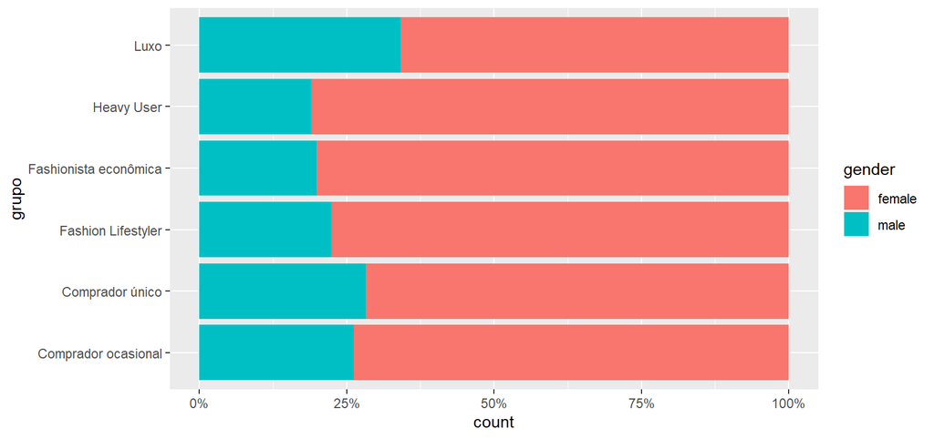

```r
clientes %>%
  filter(gender != '') %>%
  ggplot() +
  geom_bar(aes(y=grupo,fill=gender), position = 'fill')+
  scale_x_continuous(labels = scales::percent_format(), breaks = seq(0,1, by = 0.25))
```

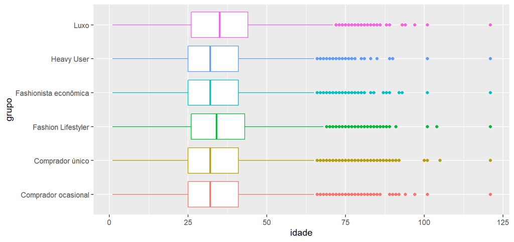

```r
clientes %>%
  ggplot() +
  geom_boxplot(aes(x=idade, y=grupo, color = grupo), show.legend = F)
```

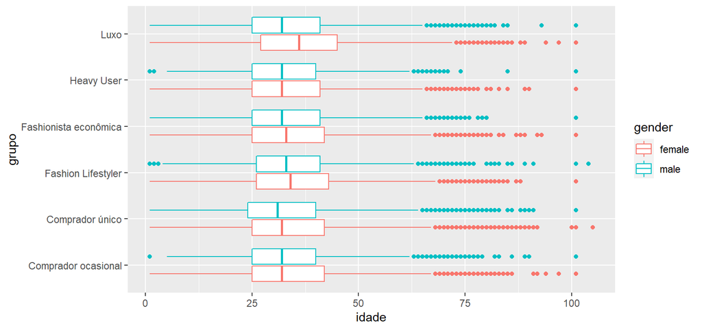

```r
clientes %>%
  filter(gender != '') %>%
  ggplot() +
  geom_boxplot(aes(x=idade, y=grupo,color=gender))
```

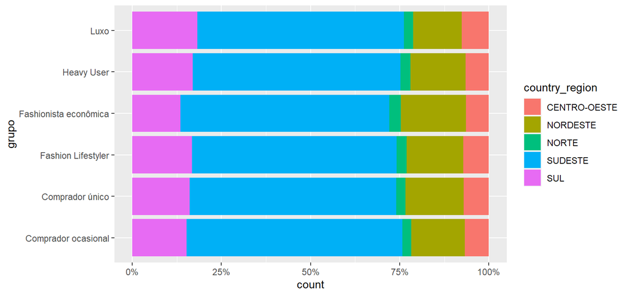

```r
clientes %>%
  ggplot() +
  geom_bar(aes(y=grupo,fill=country_region), position = 'fill')+
  scale_x_continuous(labels = scales::percent_format(), breaks = seq(0,1, by = 0.25))
```

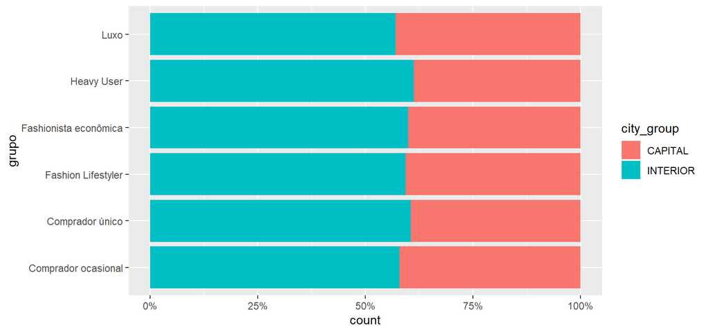

```r
clientes %>%
  ggplot() +
  geom_bar(aes(y=grupo,fill=city_group), position = 'fill')+
  scale_x_continuous(labels = scales::percent_format(), breaks = seq(0,1, by = 0.25))
```

## Mensagens

### Primeiros pushes da vida

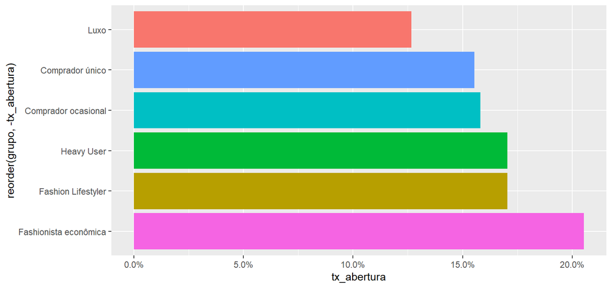

```r
gclass <- c('Fashionista econômica','Fashion Lifestyler','Heavy User','Comprador ocasional','Comprador único',  'Luxo')

group.colors <- c('Fashionista econômica' = "#F564E3", 'Fashion Lifestyler' = "#B79F00", 'Heavy User' ="#00BA38", 'Comprador ocasional' = "#00BFC4", 'Comprador único' = "#619CFF", 'Luxo' = "#F8766D")

group.colors2 <- c('Fashionista_economica' = "#F564E3", 'Fashionista_Lifestyler' = "#B79F00", 'Heavy_User' ="#00BA38", 'Comprador_Ocasional' = "#00BFC4", 'Compra_unica' = "#619CFF", 'Luxo' = "#F8766D")

documento$grupo <- factor(documento$grupo,levels=gclass)

aberturas$grupo <- factor(aberturas$segment,levels=gclass)

documento %>%
  group_by(fk_customer,grupo) %>%
  summarise(open_flag = max(open_flag)) %>%
  group_by(grupo) %>%
  summarise(tx_abertura = sum(open_flag)/n()) %>%
  ggplot() +
  geom_col(aes(x=tx_abertura, y=reorder(grupo,-tx_abertura), fill = grupo), show.legend = F)+
  scale_x_continuous(labels = scales::percent_format(), breaks = seq(0,1, by = 0.05))+
  scale_fill_manual(values=group.colors)
```

### Quaisquer pushes

Base diferente - Pushes recebidos em 03/2021

```r
aberturas %>%
  group_by(flag_estranho) %>%
  summarise(envios = sum(envios)) %>%
  mutate(porcentagem = envios/sum(envios),
         porcentagem = paste0(round(porcentagem*100,2), '%')) %>%
  knitr::kable() %>%
  kable_styling()
```

| flag_estranho | envios | porcentagem |
| --- | --- | --- |
| 0 | 43701887 | 85.11% |
| 1 | 7646592 | 14.89% |

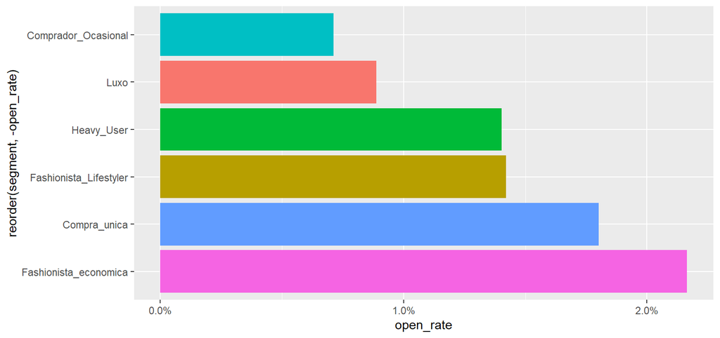

```r
aberturas %>%
  group_by(segment) %>%
  summarise(envios = sum(envios),
            aberturas = sum(aberturas),
            open_rate = aberturas/envios) %>%
  ggplot() +
  geom_col(aes(x=open_rate, y=reorder(segment,-open_rate), fill = segment), show.legend = F)+
  scale_x_continuous(labels = scales::percent_format(), breaks = seq(0,1, by = 0.01))+
  scale_fill_manual(values=group.colors2)
```

```r
media <- aberturas %>%
  group_by(segment) %>%
  summarise(envios = sum(envios),
            aberturas = sum(aberturas),
            open_rate = aberturas/envios) %>%
  select(segment,open_rate)
```

- Combos fortes para compradores únicos e compradores ocasionais
- Oferta do dia com menor open rate para todos os grupos
- Collabs forte para Fashionistas e Luxo
- Cupom maior open rate em todos os grupos, principalmente para Fashionistas economicos, lifestylers e compradores ocasionais
- Frete grátis fraco para todos os grupos
- Relampago não agrada compradores unicos e Fashionistas economicos (??)
- Metade do preço ruim para luxo, Heavy_User (?) e Fashionista_Lifestyler

#### Combo

```r
datatable(aberturas %>%
  filter(tipo_campanha == 'Combo') %>%
  group_by(segment) %>%
  summarise(envios = sum(envios),
            aberturas = sum(aberturas),
            open_rate = aberturas/envios) %>%
    select(segment,open_rate) %>%
  inner_join(media %>%
               rename(open_rate_medio = open_rate), by = 'segment') %>%
    mutate(diff = open_rate-open_rate_medio,
         diff_relativa = diff/open_rate_medio),
  caption = 'Diferença de open rate') %>%
   formatStyle(
    c('diff','diff_relativa'),
    color = styleInterval(0, c('red', 'green'))
    ) %>%
  formatPercentage (c('diff','diff_relativa','open_rate_medio','open_rate'),  digits = 2)
```

|  | segment | open_rate | open_rate_medio | diff | diff_relativa |
| --- | --- | --- | --- | --- | --- |
| 1 | Compra_unica | 0.0222165603492747 | 0.0180177910076315 | 0.00419876934164313 | 0.233034634482369 |
| 2 | Comprador_Ocasional | 0.00806787303640369 | 0.00712445962766818 | 0.000943413408735506 | 0.132418942353426 |
| 3 | Fashionista_economica | 0.0223578611968535 | 0.0216441132566713 | 0.000713747940182231 | 0.0329765387806883 |
| 4 | Fashionista_Lifestyler | 0.014171738959343 | 0.0142017253103493 | -2.99863510063308e-05 | -0.00211145831587651 |
| 5 | Heavy_User | 0.0148704299098089 | 0.0140220879563499 | 0.000848341953458998 | 0.0605004016591429 |
| 6 | Luxo | 0.00967182261953773 | 0.00887384383483038 | 0.000797978784707351 | 0.089924817199874 |

```r
  #formatRound(c('media_qtd_days_agreed', 'diferenca_2021'),  digits = 2)
```

#### A partir de

```r
datatable(aberturas %>%
  filter(tipo_campanha == 'A partir de') %>%
  group_by(segment) %>%
  summarise(envios = sum(envios),
            aberturas = sum(aberturas),
            open_rate = aberturas/envios) %>%
    select(segment,open_rate) %>%
  inner_join(media %>%
               rename(open_rate_medio = open_rate), by = 'segment') %>%
    mutate(diff = open_rate-open_rate_medio,
         diff_relativa = diff/open_rate_medio),
  caption = 'Diferença de open rate') %>%
   formatStyle(
    c('diff','diff_relativa'),
    color = styleInterval(0, c('red', 'green'))
    ) %>%
  formatPercentage (c('diff','diff_relativa','open_rate_medio','open_rate'),  digits = 2)
```

|  | segment | open_rate | open_rate_medio | diff | diff_relativa |
| --- | --- | --- | --- | --- | --- |
| 1 | Compra_unica | 0.0178894145836295 | 0.0180177910076315 | -0.000128376424002059 | -0.00712498130029837 |
| 2 | Comprador_Ocasional | 0.00732272872404462 | 0.00712445962766818 | 0.000198269096376436 | 0.0278293522229318 |
| 3 | Fashionista_economica | 0.0235537743091996 | 0.0216441132566713 | 0.00190966105252834 | 0.0882300434248435 |
| 4 | Fashionista_Lifestyler | 0.0142438979005414 | 0.0142017253103493 | 4.21725901921261e-05 | 0.00296953991649124 |
| 5 | Heavy_User | 0.0145587555613653 | 0.0140220879563499 | 0.000536667605015381 | 0.0382730165925362 |
| 6 | Luxo | 0.00829398748626449 | 0.00887384383483038 | -0.000579856348565883 | -0.0653444391583624 |

```r
  #formatRound(c('media_qtd_days_agreed', 'diferenca_2021'),  digits = 2)
```

#### Chamada “Até”

```r
datatable(aberturas %>%
  filter(tipo_campanha == 'Chamada "Até"') %>%
  group_by(segment) %>%
  summarise(envios = sum(envios),
            aberturas = sum(aberturas),
            open_rate = aberturas/envios) %>%
    select(segment,open_rate) %>%
  inner_join(media %>%
               rename(open_rate_medio = open_rate), by = 'segment') %>%
    mutate(diff = open_rate-open_rate_medio,
         diff_relativa = diff/open_rate_medio),
  caption = 'Diferença de open rate') %>%
   formatStyle(
    c('diff','diff_relativa'),
    color = styleInterval(0, c('red', 'green'))
    ) %>%
  formatPercentage (c('diff','diff_relativa','open_rate_medio','open_rate'),  digits = 2)
```

|  | segment | open_rate | open_rate_medio | diff | diff_relativa |
| --- | --- | --- | --- | --- | --- |
| 1 | Compra_unica | 0.0187689344689795 | 0.0180177910076315 | 0.000751143461348028 | 0.0416889873475543 |
| 2 | Comprador_Ocasional | 0.00730306897754143 | 0.00712445962766818 | 0.000178609349873248 | 0.0250698802726891 |
| 3 | Fashionista_economica | 0.0211196296393897 | 0.0216441132566713 | -0.00052448361728159 | -0.0242321600826003 |
| 4 | Fashionista_Lifestyler | 0.0143099922964882 | 0.0142017253103493 | 0.000108266986138954 | 0.00762350938164228 |
| 5 | Heavy_User | 0.0143618708059689 | 0.0140220879563499 | 0.000339782849619065 | 0.0242319724906015 |
| 6 | Luxo | 0.00908729981412458 | 0.00887384383483038 | 0.000213455979294203 | 0.0240545115811453 |

```r
  #formatRound(c('media_qtd_days_agreed', 'diferenca_2021'),  digits = 2)
```

#### Oferta do dia

```r
datatable(aberturas %>%
  filter(tipo_campanha == 'Oferta do dia') %>%
  group_by(segment) %>%
  summarise(envios = sum(envios),
            aberturas = sum(aberturas),
            open_rate = aberturas/envios) %>%
    select(segment,open_rate) %>%
  inner_join(media %>%
               rename(open_rate_medio = open_rate), by = 'segment') %>%
    mutate(diff = open_rate-open_rate_medio,
         diff_relativa = diff/open_rate_medio),
  caption = 'Diferença de open rate') %>%
   formatStyle(
    c('diff','diff_relativa'),
    color = styleInterval(0, c('red', 'green'))
    ) %>%
  formatPercentage (c('diff','diff_relativa','open_rate_medio','open_rate'),  digits = 2)
```

|  | segment | open_rate | open_rate_medio | diff | diff_relativa |
| --- | --- | --- | --- | --- | --- |
| 1 | Compra_unica | 0.0156128058418022 | 0.0180177910076315 | -0.00240498516582929 | -0.133478358407568 |
| 2 | Comprador_Ocasional | 0.00641769704801222 | 0.00712445962766818 | -0.00070676257965596 | -0.0992022716938719 |
| 3 | Fashionista_economica | 0.0210777549249776 | 0.0216441132566713 | -0.000566358331693727 | -0.0261668530827504 |
| 4 | Fashionista_Lifestyler | 0.0138892125825011 | 0.0142017253103493 | -0.00031251272784814 | -0.0220052649251286 |
| 5 | Heavy_User | 0.0134968719066306 | 0.0140220879563499 | -0.00052521604971926 | -0.0374563368418622 |
| 6 | Luxo | 0.00817716003870361 | 0.00887384383483038 | -0.000696683796126763 | -0.0785098103025249 |

```r
  #formatRound(c('media_qtd_days_agreed', 'diferenca_2021'),  digits = 2)
```

#### Collabs

```r
datatable(aberturas %>%
  filter(tipo_campanha == 'Collabs') %>%
  group_by(segment) %>%
  summarise(envios = sum(envios),
            aberturas = sum(aberturas),
            open_rate = aberturas/envios) %>%
    select(segment,open_rate) %>%
  inner_join(media %>%
               rename(open_rate_medio = open_rate), by = 'segment') %>%
    mutate(diff = open_rate-open_rate_medio,
         diff_relativa = diff/open_rate_medio),
  caption = 'Diferença de open rate') %>%
   formatStyle(
    c('diff','diff_relativa'),
    color = styleInterval(0, c('red', 'green'))
    ) %>%
  formatPercentage (c('diff','diff_relativa','open_rate_medio','open_rate'),  digits = 2)
```

|  | segment | open_rate | open_rate_medio | diff | diff_relativa |
| --- | --- | --- | --- | --- | --- |
| 1 | Compra_unica | 0.0163754451627875 | 0.0180177910076315 | -0.001642345844844 | -0.0911513428115789 |
| 2 | Comprador_Ocasional | 0.00686134687630444 | 0.00712445962766818 | -0.000263112751363742 | -0.0369309063584179 |
| 3 | Fashionista_economica | 0.0215071337441525 | 0.0216441132566713 | -0.000136979512518801 | -0.00632871907915099 |
| 4 | Fashionista_Lifestyler | 0.0158933457530419 | 0.0142017253103493 | 0.00169162044269257 | 0.119113727784879 |
| 5 | Heavy_User | 0.0139298427214554 | 0.0140220879563499 | -9.22452348945026e-05 | -0.00657856627213136 |
| 6 | Luxo | 0.0101688784546035 | 0.00887384383483038 | 0.00129503461977309 | 0.145938405484442 |

```r
  #formatRound(c('media_qtd_days_agreed', 'diferenca_2021'),  digits = 2)
```

#### Cupom

```r
datatable(aberturas %>%
  filter(tipo_campanha == 'Cupom') %>%
  group_by(segment) %>%
  summarise(envios = sum(envios),
            aberturas = sum(aberturas),
            open_rate = aberturas/envios) %>%
    select(segment,open_rate) %>%
  inner_join(media %>%
               rename(open_rate_medio = open_rate), by = 'segment') %>%
    mutate(diff = open_rate-open_rate_medio,
         diff_relativa = diff/open_rate_medio),
  caption = 'Diferença de open rate') %>%
   formatStyle(
    c('diff','diff_relativa'),
    color = styleInterval(0, c('red', 'green'))
    ) %>%
  formatPercentage (c('diff','diff_relativa','open_rate_medio','open_rate'),  digits = 2)
```

|  | segment | open_rate | open_rate_medio | diff | diff_relativa |
| --- | --- | --- | --- | --- | --- |
| 1 | Compra_unica | 0.0196378922411608 | 0.0180177910076315 | 0.00162010123352928 | 0.0899167513288995 |
| 2 | Comprador_Ocasional | 0.00856636534044745 | 0.00712445962766818 | 0.00144190571277927 | 0.202388081080501 |
| 3 | Fashionista_economica | 0.024357327557257 | 0.0216441132566713 | 0.00271321430058574 | 0.125355761560222 |
| 4 | Fashionista_Lifestyler | 0.0161789690516345 | 0.0142017253103493 | 0.00197724374128526 | 0.13922560097993 |
| 5 | Heavy_User | 0.0150190789756328 | 0.0140220879563499 | 0.00099699101928293 | 0.0711014666565007 |
| 6 | Luxo | 0.00972596576359133 | 0.00887384383483038 | 0.000852121928760954 | 0.0960262479959726 |

```r
  #formatRound(c('media_qtd_days_agreed', 'diferenca_2021'),  digits = 2)
```

#### Frete Gratis

```r
datatable(aberturas %>%
  filter(tipo_campanha == 'Frete Gratis') %>%
  group_by(segment) %>%
  summarise(envios = sum(envios),
            aberturas = sum(aberturas),
            open_rate = aberturas/envios) %>%
    select(segment,open_rate) %>%
  inner_join(media %>%
               rename(open_rate_medio = open_rate), by = 'segment') %>%
    mutate(diff = open_rate-open_rate_medio,
         diff_relativa = diff/open_rate_medio),
  caption = 'Diferença de open rate') %>%
   formatStyle(
    c('diff','diff_relativa'),
    color = styleInterval(0, c('red', 'green'))
    ) %>%
  formatPercentage (c('diff','diff_relativa','open_rate_medio','open_rate'),  digits = 2)
```

|  | segment | open_rate | open_rate_medio | diff | diff_relativa |
| --- | --- | --- | --- | --- | --- |
| 1 | Compra_unica | 0.0161835287640579 | 0.0180177910076315 | -0.00183426224357361 | -0.101802837140063 |
| 2 | Comprador_Ocasional | 0.00661812199749707 | 0.00712445962766818 | -0.000506337630171108 | -0.071070320646456 |
| 3 | Fashionista_economica | 0.0213393141676243 | 0.0216441132566713 | -0.00030479908904699 | -0.0140823089138587 |
| 4 | Fashionista_Lifestyler | 0.0118606188648874 | 0.0142017253103493 | -0.00234110644546189 | -0.164846622104136 |
| 5 | Heavy_User | 0.0126272988398553 | 0.0140220879563499 | -0.00139478911649462 | -0.0994708577521787 |
| 6 | Luxo | 0.00692431246572123 | 0.00887384383483038 | -0.00194953136910915 | -0.219694126400684 |

```r
  #formatRound(c('media_qtd_days_agreed', 'diferenca_2021'),  digits = 2)
```

#### Relampago

```r
datatable(aberturas %>%
  filter(tipo_campanha == 'Relampago') %>%
  group_by(segment) %>%
  summarise(envios = sum(envios),
            aberturas = sum(aberturas),
            open_rate = aberturas/envios) %>%
    select(segment,open_rate) %>%
  inner_join(media %>%
               rename(open_rate_medio = open_rate), by = 'segment') %>%
    mutate(diff = open_rate-open_rate_medio,
         diff_relativa = diff/open_rate_medio),
  caption = 'Diferença de open rate') %>%
   formatStyle(
    c('diff','diff_relativa'),
    color = styleInterval(0, c('red', 'green'))
    ) %>%
  formatPercentage (c('diff','diff_relativa','open_rate_medio','open_rate'),  digits = 2)
```

|  | segment | open_rate | open_rate_medio | diff | diff_relativa |
| --- | --- | --- | --- | --- | --- |
| 1 | Compra_unica | 0.0126475548060708 | 0.0180177910076315 | -0.00537023620156069 | -0.298051864364844 |
| 2 | Comprador_Ocasional | 0.0060631618405023 | 0.00712445962766818 | -0.00106129778716588 | -0.148965373183432 |
| 3 | Fashionista_economica | 0.0172969933712121 | 0.0216441132566713 | -0.00434711988545918 | -0.200845367694575 |
| 4 | Fashionista_Lifestyler | 0.0146896748387296 | 0.0142017253103493 | 0.000487949528380278 | 0.0343584682647462 |
| 5 | Heavy_User | 0.0153818637095332 | 0.0140220879563499 | 0.0013597757531833 | 0.0969738427983207 |
| 6 | Luxo | 0.00853224725473011 | 0.00887384383483038 | -0.000341596580100264 | -0.0384947703000448 |

```r
  #formatRound(c('media_qtd_days_agreed', 'diferenca_2021'),  digits = 2)
```

#### Metade do preco

```r
datatable(aberturas %>%
  filter(tipo_campanha == 'Metade do preco') %>%
  group_by(segment) %>%
  summarise(envios = sum(envios),
            aberturas = sum(aberturas),
            open_rate = aberturas/envios) %>%
    select(segment,open_rate) %>%
  inner_join(media %>%
               rename(open_rate_medio = open_rate), by = 'segment') %>%
    mutate(diff = open_rate-open_rate_medio,
         diff_relativa = diff/open_rate_medio),
  caption = 'Diferença de open rate') %>%
   formatStyle(
    c('diff','diff_relativa'),
    color = styleInterval(0, c('red', 'green'))
    ) %>%
  formatPercentage (c('diff','diff_relativa','open_rate_medio','open_rate'),  digits = 2)
```

|  | segment | open_rate | open_rate_medio | diff | diff_relativa |
| --- | --- | --- | --- | --- | --- |
| 1 | Compra_unica | 0.0164989939637827 | 0.0180177910076315 | -0.00151879704384882 | -0.0842942979639141 |
| 2 | Comprador_Ocasional | 0.00888779163066288 | 0.00712445962766818 | 0.0017633320029947 | 0.24750396453181 |
| 3 | Fashionista_economica | 0.0242392536402476 | 0.0216441132566713 | 0.00259514038357633 | 0.119900517651211 |
| 4 | Fashionista_Lifestyler | 0.0123310935538655 | 0.0142017253103493 | -0.00187063175648382 | -0.131718626829138 |
| 5 | Heavy_User | 0.0109602815485168 | 0.0140220879563499 | -0.00306180640783304 | -0.218355955073474 |
| 6 | Luxo | 0.00679953106682298 | 0.00887384383483038 | -0.0020743127680074 | -0.23375583418153 |

```r
  #formatRound(c('media_qtd_days_agreed', 'diferenca_2021'),  digits = 2)
```

#### Não Mapeado

```r
datatable(aberturas %>%
  filter(tipo_campanha == 'Não mapeado') %>%
  group_by(segment) %>%
  summarise(envios = sum(envios),
            aberturas = sum(aberturas),
            open_rate = aberturas/envios) %>%
    select(segment,open_rate) %>%
  inner_join(media %>%
               rename(open_rate_medio = open_rate), by = 'segment') %>%
    mutate(diff = open_rate-open_rate_medio,
         diff_relativa = diff/open_rate_medio),
  caption = 'Diferença de open rate') %>%
   formatStyle(
    c('diff','diff_relativa'),
    color = styleInterval(0, c('red', 'green'))
    ) %>%
  formatPercentage (c('diff','diff_relativa','open_rate_medio','open_rate'),  digits = 2)
```

|  | segment | open_rate | open_rate_medio | diff | diff_relativa |
| --- | --- | --- | --- | --- | --- |
| 1 | Compra_unica | 0.0190931670942933 | 0.0180177910076315 | 0.00107537608666181 | 0.0596841247745815 |
| 2 | Comprador_Ocasional | 0.00708148346394832 | 0.00712445962766818 | -4.29761637198598e-05 | -0.00603219976894245 |
| 3 | Fashionista_economica | 0.0222453331481833 | 0.0216441132566713 | 0.000601219891512003 | 0.0277775247422849 |
| 4 | Fashionista_Lifestyler | 0.0136580092525174 | 0.0142017253103493 | -0.000543716057831845 | -0.0382852115464887 |
| 5 | Heavy_User | 0.0134934845217563 | 0.0140220879563499 | -0.000528603434593588 | -0.037697911768854 |
| 6 | Luxo | 0.00891367992361967 | 0.00887384383483038 | 3.98360887892898e-05 | 0.00448915819691696 |

```r
  #formatRound(c('media_qtd_days_agreed', 'diferenca_2021'),  digits = 2)
```

## Frequencia

Pushes enviados em 03/2021

Frequencia igual a quantidade de visitas dividido pela quantidade de dias

45 dias antes do open até 45 dias após

```r
# teste_semabertura <- freq_semAbertura %>%
#   mutate(freq_pre = qtd_visitas_pre_push/45,
#          freq_pos = qtd_visitas_pos_push/45
#          )
# teste_semabertura %>%
#   summarise(freq_pre = median(freq_pre),
#             freq_pos = median(freq_pos)) %>%
#   mutate(incremento = freq_pos/freq_pre-1,
#          incremento = paste0(round(incremento*100,2),'%'),
#          freq_pre = round(freq_pre,3),
#          freq_pos = round(freq_pos,3))%>%
#   knitr::kable() %>%
#   kable_styling()
```

```r
teste <- mensagens %>%
  mutate(freq_pre = qtd_visitas_pre_push/45,
         freq_pos = qtd_visitas_pos_push/45
         )
#
# teste_semabertura %>%
#   inner_join(teste, by = 'pk_customer')
```

```r
teste %>%
  summarise(freq_pre = median(freq_pre),
            freq_pos = median(freq_pos)) %>%
  mutate(incremento = freq_pos/freq_pre-1,
         incremento = paste0(round(incremento*100,2),'%'),
         freq_pre = round(freq_pre,3),
         freq_pos = round(freq_pos,3))%>%
  knitr::kable() %>%
  kable_styling()
```

| freq_pre | freq_pos | incremento |
| --- | --- | --- |
| 0.333 | 0.333 | 0% |

```r
media_freq <- teste %>%
  group_by(segment) %>%
  summarise(freq_pre = median(freq_pre),
            freq_pos = median(freq_pos)) %>%
  mutate(incremento = freq_pos/freq_pre-1)


datatable(media_freq,
  caption = 'Média diferença de Frequencia (visitas por dia)')%>%
   formatStyle(
    c('incremento'),
    color = styleInterval(0, c('red', 'green'))
    ) %>%
  formatPercentage (c('incremento'),  digits = 2) %>%
  formatRound(c('freq_pre', 'freq_pos'),  digits = 2)
```

|  | segment | freq_pre | freq_pos | incremento |
| --- | --- | --- | --- | --- |
| 1 | Compra_unica | 0.177777777777778 | 0.2 | 0.125 |
| 2 | Comprador_Ocasional | 0.2 | 0.155555555555556 | -0.222222222222222 |
| 3 | Fashionista_economica | 0.444444444444444 | 0.444444444444444 | 0 |
| 4 | Fashionista_Lifestyler | 0.422222222222222 | 0.422222222222222 | 0 |
| 5 | Heavy_User | 0.333333333333333 | 0.355555555555556 | 0.0666666666666669 |
| 6 | Luxo | 0.266666666666667 | 0.244444444444444 | -0.0833333333333334 |

- No geral, clientes que abrem o push já tem uma frequencia de visita alta nos últimos dias (motivada por outros pushes??). Frequencia de clientes sem abertura é de ~0.15
- Combo funcionou bem para compradores ocasionais
- A partir de funcionou bem apenas para luxo
- Chamada “até” e oferta do dia pareceu funcionar bem para todos os segmentos
- Collabs e cupom bom para luxo
- Frete grátis funcionou bem para compradores ocasionais, heavy user e luxo
- metade do preço bom para todos menos compradores únicos

### Combo

```r
datatable(teste %>%
  filter(tipo_campanha == 'Combo') %>%
  group_by(segment) %>%
  summarise(freq_pre = median(freq_pre),
            freq_pos = median(freq_pos)) %>%
  inner_join(media_freq %>%
               select(segment, incremento) %>%
               rename(incremento_medio = incremento),
             by = 'segment') %>%
  mutate(incremento = freq_pos/freq_pre-1,
         diff_incremento = incremento-incremento_medio,
         diff2 = ifelse(
           diff_incremento < 0 & incremento_medio > 0, diff_incremento*-1 + incremento_medio, ifelse(
             diff_incremento > 0 & incremento_medio < 0, diff_incremento +
               incremento_medio,ifelse(
                 diff_incremento < 0 & incremento_medio < 0, 1000,2000))),
         diff_incremento_relativo = ifelse(diff2 == 1000, diff_incremento/incremento_medio*-1,
                                           ifelse(diff2 == 2000, diff_incremento/incremento_medio,
                                                  incremento_medio/diff2-1))
         ) %>%
  select(-diff2,-incremento_medio),
  caption = 'Diferença de Frequencia (visitas por dia)')%>%
   formatStyle(
    c('incremento','diff_incremento','diff_incremento_relativo'),
    color = styleInterval(0, c('red', 'green'))
    ) %>%
  formatPercentage (c('incremento','diff_incremento','diff_incremento_relativo'),  digits = 2) %>%
  formatRound(c('freq_pre', 'freq_pos'),  digits = 2)
```

|  | segment | freq_pre | freq_pos | incremento | diff_incremento | diff_incremento_relativo |
| --- | --- | --- | --- | --- | --- | --- |
| 1 | Compra_unica | 0.177777777777778 | 0.177777777777778 | 0 | -0.125 | -0.5 |
| 2 | Comprador_Ocasional | 0.177777777777778 | 0.155555555555556 | -0.125 | 0.0972222222222222 | 0.777777777777778 |
| 3 | Fashionista_economica | 0.422222222222222 | 0.444444444444444 | 0.0526315789473684 | 0.0526315789473684 |  |
| 4 | Fashionista_Lifestyler | 0.422222222222222 | 0.422222222222222 | 0 | 0 |  |
| 5 | Heavy_User | 0.333333333333333 | 0.355555555555556 | 0.0666666666666669 | 0 | 0 |
| 6 | Luxo | 0.244444444444444 | 0.222222222222222 | -0.0909090909090909 | -0.00757575757575757 | -0.0909090909090908 |

### A partir de

```r
datatable(teste %>%
  filter(tipo_campanha == 'A partir de') %>%
  group_by(segment) %>%
  summarise(freq_pre = median(freq_pre),
            freq_pos = median(freq_pos)) %>%
  inner_join(media_freq %>%
               select(segment, incremento) %>%
               rename(incremento_medio = incremento),
             by = 'segment') %>%
  mutate(incremento = freq_pos/freq_pre-1,
         diff_incremento = incremento-incremento_medio,
         diff2 = ifelse(
           diff_incremento < 0 & incremento_medio > 0, diff_incremento*-1 + incremento_medio, ifelse(
             diff_incremento > 0 & incremento_medio < 0, diff_incremento +
               incremento_medio,ifelse(
                 diff_incremento < 0 & incremento_medio < 0, 1000,2000))),
         diff_incremento_relativo = ifelse(diff2 == 1000, diff_incremento/incremento_medio*-1,
                                           ifelse(diff2 == 2000, diff_incremento/incremento_medio,
                                                  incremento_medio/diff2-1))
         ) %>%
  select(-diff2,-incremento_medio),
  caption = 'Diferença de Frequencia (visitas por dia)')%>%
   formatStyle(
    c('incremento','diff_incremento','diff_incremento_relativo'),
    color = styleInterval(0, c('red', 'green'))
    ) %>%
  formatPercentage (c('incremento','diff_incremento','diff_incremento_relativo'),  digits = 2) %>%
  formatRound(c('freq_pre', 'freq_pos'),  digits = 2)
```

|  | segment | freq_pre | freq_pos | incremento | diff_incremento | diff_incremento_relativo |
| --- | --- | --- | --- | --- | --- | --- |
| 1 | Compra_unica | 0.2 | 0.222222222222222 | 0.111111111111111 | -0.0138888888888891 | -0.100000000000001 |
| 2 | Comprador_Ocasional | 0.222222222222222 | 0.155555555555556 | -0.3 | -0.0777777777777777 | -0.35 |
| 3 | Fashionista_economica | 0.466666666666667 | 0.466666666666667 | 0 | 0 |  |
| 4 | Fashionista_Lifestyler | 0.466666666666667 | 0.444444444444444 | -0.0476190476190477 | -0.0476190476190477 |  |
| 5 | Heavy_User | 0.355555555555556 | 0.377777777777778 | 0.0625 | -0.00416666666666687 | -0.0588235294117673 |
| 6 | Luxo | 0.288888888888889 | 0.288888888888889 | 0 | 0.0833333333333334 |  |

### Chamada “Até”

```r
datatable(teste %>%
  filter(tipo_campanha == 'Chamada "Até"') %>%
  group_by(segment) %>%
  summarise(freq_pre = median(freq_pre),
            freq_pos = median(freq_pos)) %>%
  inner_join(media_freq%>%
               select(segment, incremento) %>%
               rename(incremento_medio = incremento),
             by = 'segment') %>%
  mutate(incremento = freq_pos/freq_pre-1,
         diff_incremento = incremento-incremento_medio,
         diff2 = ifelse(
           diff_incremento < 0 & incremento_medio > 0, diff_incremento*-1 + incremento_medio, ifelse(
             diff_incremento > 0 & incremento_medio < 0, diff_incremento +
               incremento_medio,ifelse(
                 diff_incremento < 0 & incremento_medio < 0, 1000,2000))),
         diff_incremento_relativo = ifelse(diff2 == 1000, diff_incremento/incremento_medio*-1,
                                           ifelse(diff2 == 2000, diff_incremento/incremento_medio,
                                                  incremento_medio/diff2-1))
         ) %>%
  select(-diff2,-incremento_medio),
  caption = 'Diferença de Frequencia (visitas por dia)')%>%
   formatStyle(
    c('incremento','diff_incremento','diff_incremento_relativo'),
    color = styleInterval(0, c('red', 'green'))
    ) %>%
  formatPercentage (c('incremento','diff_incremento','diff_incremento_relativo'),  digits = 2) %>%
  formatRound(c('freq_pre', 'freq_pos'),  digits = 2)
```

|  | segment | freq_pre | freq_pos | incremento | diff_incremento | diff_incremento_relativo |
| --- | --- | --- | --- | --- | --- | --- |
| 1 | Compra_unica | 0.155555555555556 | 0.177777777777778 | 0.142857142857143 | 0.0178571428571428 | 0.142857142857142 |
| 2 | Comprador_Ocasional | 0.177777777777778 | 0.155555555555556 | -0.125 | 0.0972222222222222 | 0.777777777777778 |
| 3 | Fashionista_economica | 0.377777777777778 | 0.377777777777778 | 0 | 0 |  |
| 4 | Fashionista_Lifestyler | 0.355555555555556 | 0.377777777777778 | 0.0625 | 0.0625 |  |
| 5 | Heavy_User | 0.288888888888889 | 0.333333333333333 | 0.153846153846154 | 0.0871794871794871 | 1.3076923076923 |
| 6 | Luxo | 0.222222222222222 | 0.222222222222222 | 0 | 0.0833333333333334 |  |

### Oferta do dia

```r
datatable(teste %>%
  filter(tipo_campanha == 'Oferta do dia') %>%
  group_by(segment) %>%
  summarise(freq_pre = median(freq_pre),
            freq_pos = median(freq_pos)) %>%
  inner_join(media_freq%>%
               select(segment, incremento) %>%
               rename(incremento_medio = incremento),
             by = 'segment') %>%
  mutate(incremento = freq_pos/freq_pre-1,
         diff_incremento = incremento-incremento_medio,
         diff2 = ifelse(
           diff_incremento < 0 & incremento_medio > 0, diff_incremento*-1 + incremento_medio, ifelse(
             diff_incremento > 0 & incremento_medio < 0, diff_incremento +
               incremento_medio,ifelse(
                 diff_incremento < 0 & incremento_medio < 0, 1000,2000))),
         diff_incremento_relativo = ifelse(diff2 == 1000, diff_incremento/incremento_medio*-1,
                                           ifelse(diff2 == 2000, diff_incremento/incremento_medio,
                                                  incremento_medio/diff2-1))
         ) %>%
  select(-diff2,-incremento_medio),
  caption = 'Diferença de Frequencia (visitas por dia)')%>%
   formatStyle(
    c('incremento','diff_incremento','diff_incremento_relativo'),
    color = styleInterval(0, c('red', 'green'))
    ) %>%
  formatPercentage (c('incremento','diff_incremento','diff_incremento_relativo'),  digits = 2) %>%
  formatRound(c('freq_pre', 'freq_pos'),  digits = 2)
```

|  | segment | freq_pre | freq_pos | incremento | diff_incremento | diff_incremento_relativo |
| --- | --- | --- | --- | --- | --- | --- |
| 1 | Compra_unica | 0.155555555555556 | 0.2 | 0.285714285714286 | 0.160714285714286 | 1.28571428571429 |
| 2 | Comprador_Ocasional | 0.177777777777778 | 0.155555555555556 | -0.125 | 0.0972222222222222 | 0.777777777777778 |
| 3 | Fashionista_economica | 0.377777777777778 | 0.4 | 0.0588235294117647 | 0.0588235294117647 |  |
| 4 | Fashionista_Lifestyler | 0.4 | 0.4 | 0 | 0 |  |
| 5 | Heavy_User | 0.311111111111111 | 0.355555555555556 | 0.142857142857143 | 0.0761904761904759 | 1.14285714285714 |
| 6 | Luxo | 0.244444444444444 | 0.244444444444444 | 0 | 0.0833333333333334 |  |

### Collabs

```r
datatable(teste %>%
  filter(tipo_campanha == 'Collabs') %>%
  group_by(segment) %>%
  summarise(freq_pre = median(freq_pre),
            freq_pos = median(freq_pos)) %>%
  inner_join(media_freq%>%
               select(segment, incremento) %>%
               rename(incremento_medio = incremento),
             by = 'segment') %>%
  mutate(incremento = freq_pos/freq_pre-1,
         diff_incremento = incremento-incremento_medio,
         diff2 = ifelse(
           diff_incremento < 0 & incremento_medio > 0, diff_incremento*-1 + incremento_medio, ifelse(
             diff_incremento > 0 & incremento_medio < 0, diff_incremento +
               incremento_medio,ifelse(
                 diff_incremento < 0 & incremento_medio < 0, 1000,2000))),
         diff_incremento_relativo = ifelse(diff2 == 1000, diff_incremento/incremento_medio*-1,
                                           ifelse(diff2 == 2000, diff_incremento/incremento_medio,
                                                  incremento_medio/diff2-1))
         ) %>%
  select(-diff2,-incremento_medio),
  caption = 'Diferença de Frequencia (visitas por dia)')%>%
   formatStyle(
    c('incremento','diff_incremento','diff_incremento_relativo'),
    color = styleInterval(0, c('red', 'green'))
    ) %>%
  formatPercentage (c('incremento','diff_incremento','diff_incremento_relativo'),  digits = 2) %>%
  formatRound(c('freq_pre', 'freq_pos'),  digits = 2)
```

|  | segment | freq_pre | freq_pos | incremento | diff_incremento | diff_incremento_relativo |
| --- | --- | --- | --- | --- | --- | --- |
| 1 | Compra_unica | 0.222222222222222 | 0.2 | -0.0999999999999999 | -0.225 | -0.642857142857143 |
| 2 | Comprador_Ocasional | 0.222222222222222 | 0.177777777777778 | -0.2 | 0.0222222222222223 | 0.111111111111111 |
| 3 | Fashionista_economica | 0.466666666666667 | 0.466666666666667 | 0 | 0 |  |
| 4 | Fashionista_Lifestyler | 0.488888888888889 | 0.466666666666667 | -0.0454545454545454 | -0.0454545454545454 |  |
| 5 | Heavy_User | 0.377777777777778 | 0.377777777777778 | 0 | -0.0666666666666669 | -0.5 |
| 6 | Luxo | 0.333333333333333 | 0.333333333333333 | 0 | 0.0833333333333334 |  |

### Cupom

```r
datatable(teste %>%
  filter(tipo_campanha == 'Cupom') %>%
  group_by(segment) %>%
  summarise(freq_pre = median(freq_pre),
            freq_pos = median(freq_pos)) %>%
  inner_join(media_freq%>%
               select(segment, incremento) %>%
               rename(incremento_medio = incremento),
             by = 'segment') %>%
  mutate(incremento = freq_pos/freq_pre-1,
         diff_incremento = incremento-incremento_medio,
         diff2 = ifelse(
           diff_incremento < 0 & incremento_medio > 0, diff_incremento*-1 + incremento_medio, ifelse(
             diff_incremento > 0 & incremento_medio < 0, diff_incremento +
               incremento_medio,ifelse(
                 diff_incremento < 0 & incremento_medio < 0, 1000,2000))),
         diff_incremento_relativo = ifelse(diff2 == 1000, diff_incremento/incremento_medio*-1,
                                           ifelse(diff2 == 2000, diff_incremento/incremento_medio,
                                                  incremento_medio/diff2-1))
         ) %>%
  select(-diff2,-incremento_medio),
  caption = 'Diferença de Frequencia (visitas por dia)')%>%
   formatStyle(
    c('incremento','diff_incremento','diff_incremento_relativo'),
    color = styleInterval(0, c('red', 'green'))
    ) %>%
  formatPercentage (c('incremento','diff_incremento','diff_incremento_relativo'),  digits = 2) %>%
  formatRound(c('freq_pre', 'freq_pos'),  digits = 2)
```

|  | segment | freq_pre | freq_pos | incremento | diff_incremento | diff_incremento_relativo |
| --- | --- | --- | --- | --- | --- | --- |
| 1 | Compra_unica | 0.2 | 0.2 | 0 | -0.125 | -0.5 |
| 2 | Comprador_Ocasional | 0.2 | 0.177777777777778 | -0.111111111111111 | 0.111111111111111 | 0.999999999999999 |
| 3 | Fashionista_economica | 0.466666666666667 | 0.466666666666667 | 0 | 0 |  |
| 4 | Fashionista_Lifestyler | 0.466666666666667 | 0.466666666666667 | 0 | 0 |  |
| 5 | Heavy_User | 0.355555555555556 | 0.377777777777778 | 0.0625 | -0.00416666666666687 | -0.0588235294117673 |
| 6 | Luxo | 0.288888888888889 | 0.288888888888889 | 0 | 0.0833333333333334 |  |

### Frete Gratis

```r
datatable(teste %>%
  filter(tipo_campanha == 'Frete Gratis') %>%
  group_by(segment) %>%
  summarise(freq_pre = median(freq_pre),
            freq_pos = median(freq_pos)) %>%
  inner_join(media_freq%>%
               select(segment, incremento) %>%
               rename(incremento_medio = incremento),
             by = 'segment') %>%
  mutate(incremento = freq_pos/freq_pre-1,
         diff_incremento = incremento-incremento_medio,
         diff2 = ifelse(
           diff_incremento < 0 & incremento_medio > 0, diff_incremento*-1 + incremento_medio, ifelse(
             diff_incremento > 0 & incremento_medio < 0, diff_incremento +
               incremento_medio,ifelse(
                 diff_incremento < 0 & incremento_medio < 0, 1000,2000))),
         diff_incremento_relativo = ifelse(diff2 == 1000, diff_incremento/incremento_medio*-1,
                                           ifelse(diff2 == 2000, diff_incremento/incremento_medio,
                                                  incremento_medio/diff2-1))
         ) %>%
  select(-diff2,-incremento_medio),
  caption = 'Diferença de Frequencia (visitas por dia)')%>%
   formatStyle(
    c('incremento','diff_incremento','diff_incremento_relativo'),
    color = styleInterval(0, c('red', 'green'))
    ) %>%
  formatPercentage (c('incremento','diff_incremento','diff_incremento_relativo'),  digits = 2) %>%
  formatRound(c('freq_pre', 'freq_pos'),  digits = 2)
```

|  | segment | freq_pre | freq_pos | incremento | diff_incremento | diff_incremento_relativo |
| --- | --- | --- | --- | --- | --- | --- |
| 1 | Compra_unica | 0.2 | 0.222222222222222 | 0.111111111111111 | -0.0138888888888891 | -0.100000000000001 |
| 2 | Comprador_Ocasional | 0.222222222222222 | 0.2 | -0.0999999999999999 | 0.122222222222222 | 1.22222222222222 |
| 3 | Fashionista_economica | 0.511111111111111 | 0.511111111111111 | 0 | 0 |  |
| 4 | Fashionista_Lifestyler | 0.533333333333333 | 0.511111111111111 | -0.0416666666666667 | -0.0416666666666667 |  |
| 5 | Heavy_User | 0.377777777777778 | 0.422222222222222 | 0.117647058823529 | 0.0509803921568626 | 0.764705882352936 |
| 6 | Luxo | 0.333333333333333 | 0.311111111111111 | -0.0666666666666667 | 0.0166666666666667 | 0.250000000000001 |

### Relampago

```r
datatable(teste %>%
  filter(tipo_campanha == 'Relampago') %>%
  group_by(segment) %>%
  summarise(freq_pre = median(freq_pre),
            freq_pos = median(freq_pos)) %>%
  inner_join(media_freq%>%
               select(segment, incremento) %>%
               rename(incremento_medio = incremento),
             by = 'segment') %>%
  mutate(incremento = freq_pos/freq_pre-1,
         diff_incremento = incremento-incremento_medio,
         diff2 = ifelse(
           diff_incremento < 0 & incremento_medio > 0, diff_incremento*-1 + incremento_medio, ifelse(
             diff_incremento > 0 & incremento_medio < 0, diff_incremento +
               incremento_medio,ifelse(
                 diff_incremento < 0 & incremento_medio < 0, 1000,2000))),
         diff_incremento_relativo = ifelse(diff2 == 1000, diff_incremento/incremento_medio*-1,
                                           ifelse(diff2 == 2000, diff_incremento/incremento_medio,
                                                  incremento_medio/diff2-1))
         ) %>%
  select(-diff2,-incremento_medio),
  caption = 'Diferença de Frequencia (visitas por dia)')%>%
   formatStyle(
    c('incremento','diff_incremento','diff_incremento_relativo'),
    color = styleInterval(0, c('red', 'green'))
    ) %>%
  formatPercentage (c('incremento','diff_incremento','diff_incremento_relativo'),  digits = 2) %>%
  formatRound(c('freq_pre', 'freq_pos'),  digits = 2)
```

|  | segment | freq_pre | freq_pos | incremento | diff_incremento | diff_incremento_relativo |
| --- | --- | --- | --- | --- | --- | --- |
| 1 | Compra_unica | 0.244444444444444 | 0.2 | -0.181818181818182 | -0.306818181818182 | -0.710526315789474 |
| 2 | Comprador_Ocasional | 0.2 | 0.155555555555556 | -0.222222222222222 | 0 | 0 |
| 3 | Fashionista_economica | 0.511111111111111 | 0.5 | -0.0217391304347825 | -0.0217391304347825 |  |
| 4 | Fashionista_Lifestyler | 0.466666666666667 | 0.466666666666667 | 0 | 0 |  |
| 5 | Heavy_User | 0.4 | 0.4 | 0 | -0.0666666666666669 | -0.5 |
| 6 | Luxo | 0.311111111111111 | 0.288888888888889 | -0.0714285714285715 | 0.0119047619047619 | 0.166666666666666 |

### Metade do preco

```r
datatable(teste %>%
  filter(tipo_campanha == 'Metade do preco') %>%
  group_by(segment) %>%
  summarise(freq_pre = median(freq_pre),
            freq_pos = median(freq_pos)) %>%
  inner_join(media_freq%>%
               select(segment, incremento) %>%
               rename(incremento_medio = incremento),
             by = 'segment') %>%
  mutate(incremento = freq_pos/freq_pre-1,
         diff_incremento = incremento-incremento_medio,
         diff2 = ifelse(
           diff_incremento < 0 & incremento_medio > 0, diff_incremento*-1 + incremento_medio, ifelse(
             diff_incremento > 0 & incremento_medio < 0, 3000,
              ifelse(diff_incremento < 0 & incremento_medio < 0, 1000,
                     2000))),
         diff_incremento_relativo = ifelse(diff2 == 1000, diff_incremento/incremento_medio*-1,
                                           ifelse(diff2 == 2000, diff_incremento/incremento_medio,
                                                  ifelse(diff2 == 3000, diff_incremento/(-incremento_medio),
                                                         incremento_medio/diff2-1)))
         ) %>%
  select(-diff2,-incremento_medio),
  caption = 'Diferença de Frequencia (visitas por dia)')%>%
   formatStyle(
    c('incremento','diff_incremento','diff_incremento_relativo'),
    color = styleInterval(0, c('red', 'green'))
    ) %>%
  formatPercentage (c('incremento','diff_incremento','diff_incremento_relativo'),  digits = 2) %>%
  formatRound(c('freq_pre', 'freq_pos'),  digits = 2)
```

|  | segment | freq_pre | freq_pos | incremento | diff_incremento | diff_incremento_relativo |
| --- | --- | --- | --- | --- | --- | --- |
| 1 | Compra_unica | 0.333333333333333 | 0.311111111111111 | -0.0666666666666667 | -0.191666666666667 | -0.605263157894737 |
| 2 | Comprador_Ocasional | 0.222222222222222 | 0.2 | -0.0999999999999999 | 0.122222222222222 | 0.550000000000001 |
| 3 | Fashionista_economica | 0.555555555555556 | 0.6 | 0.0799999999999998 | 0.0799999999999998 |  |
| 4 | Fashionista_Lifestyler | 0.511111111111111 | 0.533333333333333 | 0.0434782608695652 | 0.0434782608695652 |  |
| 5 | Heavy_User | 0.355555555555556 | 0.466666666666667 | 0.3125 | 0.245833333333333 | 3.68749999999999 |
| 6 | Luxo | 0.266666666666667 | 0.311111111111111 | 0.166666666666667 | 0.25 | 3 |

## Open Rate X Frequencia

```r
media2 <- media_freq %>%
  inner_join(
    aberturas %>%
      group_by(segment) %>%
      summarise(envios = sum(envios),
                aberturas = sum(aberturas),
                open_rate = aberturas/envios) %>%
    select(segment,open_rate),
    by = 'segment'
  ) %>%
  rename(diff_frequencia = incremento) %>%
  select(segment,open_rate,diff_frequencia)

datatable(media2,
  caption = 'Open rate e Frequencia')%>%
   formatStyle(
    c('diff_frequencia'),
    color = styleInterval(0, c('red', 'green'))
    ) %>%
  formatPercentage (c('open_rate','diff_frequencia'),  digits = 2)
```

|  | segment | open_rate | diff_frequencia |
| --- | --- | --- | --- |
| 1 | Compra_unica | 0.0180177910076315 | 0.125 |
| 2 | Comprador_Ocasional | 0.00712445962766818 | -0.222222222222222 |
| 3 | Fashionista_economica | 0.0216441132566713 | 0 |
| 4 | Fashionista_Lifestyler | 0.0142017253103493 | 0 |
| 5 | Heavy_User | 0.0140220879563499 | 0.0666666666666669 |
| 6 | Luxo | 0.00887384383483038 | -0.0833333333333334 |

### Combo

```r
teste2 <- teste %>%
  filter(tipo_campanha == 'Combo') %>%
  group_by(segment) %>%
  summarise(freq_pre = median(freq_pre),
            freq_pos = median(freq_pos)) %>%
  inner_join(media_freq %>%
               select(segment, incremento) %>%
               rename(incremento_medio = incremento),
             by = 'segment') %>%
  mutate(incremento = freq_pos/freq_pre-1,
         diff_incremento = incremento-incremento_medio,
         diff2 = ifelse(
           diff_incremento < 0 & incremento_medio > 0, diff_incremento*-1 + incremento_medio, ifelse(
             diff_incremento > 0 & incremento_medio < 0, diff_incremento +
               incremento_medio*-1,ifelse(
                 diff_incremento < 0 & incremento_medio < 0, 1000,2000))),
         diff_incremento_relativo = ifelse(diff2 == 1000, diff_incremento/incremento_medio*-1,
                                           ifelse(diff2 == 2000, diff_incremento/incremento_medio,
                                                  incremento_medio/diff2-1))
         )%>%
  select(segment,diff_incremento_relativo)

media2 <- teste2 %>%
  inner_join(
    aberturas %>%
      filter(tipo_campanha == 'Combo') %>%
      group_by(segment) %>%
      summarise(envios = sum(envios),
            aberturas = sum(aberturas),
            open_rate = aberturas/envios) %>%
    select(segment,open_rate) %>%
      inner_join(media %>%
                   rename(open_rate_medio = open_rate), by = 'segment') %>%
      mutate(diff = open_rate-open_rate_medio,
             diff_relativa = diff/open_rate_medio) %>%
      select(segment, diff_relativa),
    by = 'segment'
  ) %>%
  rename(diff_open_rate = diff_relativa,
         diff_frequencia = diff_incremento_relativo) %>%
  select(segment,diff_open_rate,diff_frequencia)


datatable(media2,
  caption = 'Open rate e Frequencia')%>%
   formatStyle(
    c('diff_frequencia','diff_open_rate'),
    color = styleInterval(0, c('red', 'green'))
    ) %>%
  formatPercentage (c('diff_open_rate','diff_frequencia'),  digits = 2)
```

|  | segment | diff_open_rate | diff_frequencia |
| --- | --- | --- | --- |
| 1 | Compra_unica | 0.233034634482369 | -0.5 |
| 2 | Comprador_Ocasional | 0.132418942353426 | -1.69565217391304 |
| 3 | Fashionista_economica | 0.0329765387806883 |  |
| 4 | Fashionista_Lifestyler | -0.00211145831587651 |  |
| 5 | Heavy_User | 0.0605004016591429 | 0 |
| 6 | Luxo | 0.089924817199874 | -0.0909090909090908 |

### A partir de

```r
teste2 <- teste %>%
  filter(tipo_campanha == 'A partir de') %>%
  group_by(segment) %>%
  summarise(freq_pre = median(freq_pre),
            freq_pos = median(freq_pos)) %>%
  inner_join(media_freq %>%
               select(segment, incremento) %>%
               rename(incremento_medio = incremento),
             by = 'segment') %>%
  mutate(incremento = freq_pos/freq_pre-1,
         diff_incremento = incremento-incremento_medio,
         diff2 = ifelse(
           diff_incremento < 0 & incremento_medio > 0, diff_incremento*-1 + incremento_medio, ifelse(
             diff_incremento > 0 & incremento_medio < 0, diff_incremento +
               incremento_medio*-1,ifelse(
                 diff_incremento < 0 & incremento_medio < 0, 1000,2000))),
         diff_incremento_relativo = ifelse(diff2 == 1000, diff_incremento/incremento_medio*-1,
                                           ifelse(diff2 == 2000, diff_incremento/incremento_medio,
                                                  incremento_medio/diff2-1))
         )%>%
  select(segment,diff_incremento_relativo)

media2 <- teste2 %>%
  inner_join(
    aberturas %>%
      filter(tipo_campanha == 'A partir de') %>%
      group_by(segment) %>%
      summarise(envios = sum(envios),
            aberturas = sum(aberturas),
            open_rate = aberturas/envios) %>%
      inner_join(media %>%
                   rename(open_rate_medio = open_rate), by = 'segment') %>%
      mutate(diff = open_rate-open_rate_medio,
             diff_relativa = diff/open_rate_medio) %>%
      select(segment, diff_relativa),
    by = 'segment'
  ) %>%
  rename(diff_open_rate = diff_relativa,
         diff_frequencia = diff_incremento_relativo) %>%
  select(segment,diff_open_rate,diff_frequencia)


datatable(media2,
  caption = 'Open rate e Frequencia')%>%
   formatStyle(
    c('diff_frequencia','diff_open_rate'),
    color = styleInterval(0, c('red', 'green'))
    ) %>%
  formatPercentage (c('diff_open_rate','diff_frequencia'),  digits = 2)
```

|  | segment | diff_open_rate | diff_frequencia |
| --- | --- | --- | --- |
| 1 | Compra_unica | -0.00712498130029837 | -0.100000000000001 |
| 2 | Comprador_Ocasional | 0.0278293522229318 | -0.35 |
| 3 | Fashionista_economica | 0.0882300434248435 |  |
| 4 | Fashionista_Lifestyler | 0.00296953991649124 |  |
| 5 | Heavy_User | 0.0382730165925362 | -0.0588235294117673 |
| 6 | Luxo | -0.0653444391583624 | -1.5 |

### Chamada “Até”

```r
teste2 <- teste %>%
  filter(tipo_campanha == 'Chamada "Até"') %>%
  group_by(segment) %>%
  summarise(freq_pre = median(freq_pre),
            freq_pos = median(freq_pos)) %>%
  inner_join(media_freq %>%
               select(segment, incremento) %>%
               rename(incremento_medio = incremento),
             by = 'segment') %>%
  mutate(incremento = freq_pos/freq_pre-1,
         diff_incremento = incremento-incremento_medio,
         diff2 = ifelse(
           diff_incremento < 0 & incremento_medio > 0, diff_incremento*-1 + incremento_medio, ifelse(
             diff_incremento > 0 & incremento_medio < 0, diff_incremento +
               incremento_medio*-1,ifelse(
                 diff_incremento < 0 & incremento_medio < 0, 1000,2000))),
         diff_incremento_relativo = ifelse(diff2 == 1000, diff_incremento/incremento_medio*-1,
                                           ifelse(diff2 == 2000, diff_incremento/incremento_medio,
                                                  incremento_medio/diff2-1))
         )%>%
  select(segment,diff_incremento_relativo)

media2 <- teste2 %>%
  inner_join(
    aberturas %>%
      filter(tipo_campanha == 'Chamada "Até"') %>%
      group_by(segment) %>%
      summarise(envios = sum(envios),
            aberturas = sum(aberturas),
            open_rate = aberturas/envios) %>%
      inner_join(media %>%
                   rename(open_rate_medio = open_rate), by = 'segment') %>%
      mutate(diff = open_rate-open_rate_medio,
             diff_relativa = diff/open_rate_medio) %>%
      select(segment, diff_relativa),
    by = 'segment'
  ) %>%
  rename(diff_open_rate = diff_relativa,
         diff_frequencia = diff_incremento_relativo) %>%
  select(segment,diff_open_rate,diff_frequencia)


datatable(media2,
  caption = 'Open rate e Frequencia')%>%
   formatStyle(
    c('diff_frequencia','diff_open_rate'),
    color = styleInterval(0, c('red', 'green'))
    ) %>%
  formatPercentage (c('diff_open_rate','diff_frequencia'),  digits = 2)
```

|  | segment | diff_open_rate | diff_frequencia |
| --- | --- | --- | --- |
| 1 | Compra_unica | 0.0416889873475543 | 0.142857142857142 |
| 2 | Comprador_Ocasional | 0.0250698802726891 | -1.69565217391304 |
| 3 | Fashionista_economica | -0.0242321600826003 |  |
| 4 | Fashionista_Lifestyler | 0.00762350938164228 |  |
| 5 | Heavy_User | 0.0242319724906015 | 1.3076923076923 |
| 6 | Luxo | 0.0240545115811453 | -1.5 |

### Oferta do dia

```r
teste2 <- teste %>%
  filter(tipo_campanha == 'Oferta do dia') %>%
  group_by(segment) %>%
  summarise(freq_pre = median(freq_pre),
            freq_pos = median(freq_pos)) %>%
  inner_join(media_freq %>%
               select(segment, incremento) %>%
               rename(incremento_medio = incremento),
             by = 'segment') %>%
  mutate(incremento = freq_pos/freq_pre-1,
         diff_incremento = incremento-incremento_medio,
         diff2 = ifelse(
           diff_incremento < 0 & incremento_medio > 0, diff_incremento*-1 + incremento_medio, ifelse(
             diff_incremento > 0 & incremento_medio < 0, diff_incremento +
               incremento_medio*-1,ifelse(
                 diff_incremento < 0 & incremento_medio < 0, 1000,2000))),
         diff_incremento_relativo = ifelse(diff2 == 1000, diff_incremento/incremento_medio*-1,
                                           ifelse(diff2 == 2000, diff_incremento/incremento_medio,
                                                  incremento_medio/diff2-1))
         )%>%
  select(segment,diff_incremento_relativo)

media2 <- teste2 %>%
  inner_join(
    aberturas %>%
      filter(tipo_campanha == 'Oferta do dia') %>%
      group_by(segment) %>%
      summarise(envios = sum(envios),
            aberturas = sum(aberturas),
            open_rate = aberturas/envios) %>%
      inner_join(media %>%
                   rename(open_rate_medio = open_rate), by = 'segment') %>%
      mutate(diff = open_rate-open_rate_medio,
             diff_relativa = diff/open_rate_medio) %>%
      select(segment, diff_relativa),
    by = 'segment'
  ) %>%
  rename(diff_open_rate = diff_relativa,
         diff_frequencia = diff_incremento_relativo) %>%
  select(segment,diff_open_rate,diff_frequencia)


datatable(media2,
  caption = 'Open rate e Frequencia')%>%
   formatStyle(
    c('diff_frequencia','diff_open_rate'),
    color = styleInterval(0, c('red', 'green'))
    ) %>%
  formatPercentage (c('diff_open_rate','diff_frequencia'),  digits = 2)
```

|  | segment | diff_open_rate | diff_frequencia |
| --- | --- | --- | --- |
| 1 | Compra_unica | -0.133478358407568 | 1.28571428571429 |
| 2 | Comprador_Ocasional | -0.0992022716938719 | -1.69565217391304 |
| 3 | Fashionista_economica | -0.0261668530827504 |  |
| 4 | Fashionista_Lifestyler | -0.0220052649251286 |  |
| 5 | Heavy_User | -0.0374563368418622 | 1.14285714285714 |
| 6 | Luxo | -0.0785098103025249 | -1.5 |

### Collabs

```r
teste2 <- teste %>%
  filter(tipo_campanha == 'Collabs') %>%
  group_by(segment) %>%
  summarise(freq_pre = median(freq_pre),
            freq_pos = median(freq_pos)) %>%
  inner_join(media_freq %>%
               select(segment, incremento) %>%
               rename(incremento_medio = incremento),
             by = 'segment') %>%
  mutate(incremento = freq_pos/freq_pre-1,
         diff_incremento = incremento-incremento_medio,
         diff2 = ifelse(
           diff_incremento < 0 & incremento_medio > 0, diff_incremento*-1 + incremento_medio, ifelse(
             diff_incremento > 0 & incremento_medio < 0, diff_incremento +
               incremento_medio*-1,ifelse(
                 diff_incremento < 0 & incremento_medio < 0, 1000,2000))),
         diff_incremento_relativo = ifelse(diff2 == 1000, diff_incremento/incremento_medio*-1,
                                           ifelse(diff2 == 2000, diff_incremento/incremento_medio,
                                                  incremento_medio/diff2-1))
         )%>%
  select(segment,diff_incremento_relativo)

media2 <- teste2 %>%
  inner_join(
    aberturas %>%
      filter(tipo_campanha == 'Collabs') %>%
      group_by(segment) %>%
      summarise(envios = sum(envios),
            aberturas = sum(aberturas),
            open_rate = aberturas/envios)%>%
      inner_join(media %>%
                   rename(open_rate_medio = open_rate), by = 'segment') %>%
      mutate(diff = open_rate-open_rate_medio,
             diff_relativa = diff/open_rate_medio) %>%
      select(segment, diff_relativa),
    by = 'segment'
  ) %>%
  rename(diff_open_rate = diff_relativa,
         diff_frequencia = diff_incremento_relativo) %>%
  select(segment,diff_open_rate,diff_frequencia)


datatable(media2,
  caption = 'Open rate e Frequencia')%>%
   formatStyle(
    c('diff_frequencia','diff_open_rate'),
    color = styleInterval(0, c('red', 'green'))
    ) %>%
  formatPercentage (c('diff_open_rate','diff_frequencia'),  digits = 2)
```

|  | segment | diff_open_rate | diff_frequencia |
| --- | --- | --- | --- |
| 1 | Compra_unica | -0.0911513428115789 | -0.642857142857143 |
| 2 | Comprador_Ocasional | -0.0369309063584179 | -1.90909090909091 |
| 3 | Fashionista_economica | -0.00632871907915099 |  |
| 4 | Fashionista_Lifestyler | 0.119113727784879 |  |
| 5 | Heavy_User | -0.00657856627213136 | -0.5 |
| 6 | Luxo | 0.145938405484442 | -1.5 |

### Cupom

```r
teste2 <- teste %>%
  filter(tipo_campanha == 'Cupom') %>%
  group_by(segment) %>%
  summarise(freq_pre = median(freq_pre),
            freq_pos = median(freq_pos)) %>%
  inner_join(media_freq %>%
               select(segment, incremento) %>%
               rename(incremento_medio = incremento),
             by = 'segment') %>%
  mutate(incremento = freq_pos/freq_pre-1,
         diff_incremento = incremento-incremento_medio,
         diff2 = ifelse(
           diff_incremento < 0 & incremento_medio > 0, diff_incremento*-1 + incremento_medio, ifelse(
             diff_incremento > 0 & incremento_medio < 0, diff_incremento +
               incremento_medio*-1,ifelse(
                 diff_incremento < 0 & incremento_medio < 0, 1000,2000))),
         diff_incremento_relativo = ifelse(diff2 == 1000, diff_incremento/incremento_medio*-1,
                                           ifelse(diff2 == 2000, diff_incremento/incremento_medio,
                                                  incremento_medio/diff2-1))
         )%>%
  select(segment,diff_incremento_relativo)

media2 <- teste2 %>%
  inner_join(
    aberturas %>%
      filter(tipo_campanha == 'Cupom') %>%
      group_by(segment) %>%
      summarise(envios = sum(envios),
            aberturas = sum(aberturas),
            open_rate = aberturas/envios) %>%
      inner_join(media %>%
                   rename(open_rate_medio = open_rate), by = 'segment') %>%
      mutate(diff = open_rate-open_rate_medio,
             diff_relativa = diff/open_rate_medio) %>%
      select(segment, diff_relativa),
    by = 'segment'
  ) %>%
  rename(diff_open_rate = diff_relativa,
         diff_frequencia = diff_incremento_relativo) %>%
  select(segment,diff_open_rate,diff_frequencia)


datatable(media2,
  caption = 'Open rate e Frequencia')%>%
   formatStyle(
    c('diff_frequencia','diff_open_rate'),
    color = styleInterval(0, c('red', 'green'))
    ) %>%
  formatPercentage (c('diff_open_rate','diff_frequencia'),  digits = 2)
```

|  | segment | diff_open_rate | diff_frequencia |
| --- | --- | --- | --- |
| 1 | Compra_unica | 0.0899167513288995 | -0.5 |
| 2 | Comprador_Ocasional | 0.202388081080501 | -1.66666666666667 |
| 3 | Fashionista_economica | 0.125355761560222 |  |
| 4 | Fashionista_Lifestyler | 0.13922560097993 |  |
| 5 | Heavy_User | 0.0711014666565007 | -0.0588235294117673 |
| 6 | Luxo | 0.0960262479959726 | -1.5 |

### Frete Gratis

```r
teste2 <- teste %>%
  filter(tipo_campanha == 'Frete Gratis') %>%
  group_by(segment) %>%
  summarise(freq_pre = median(freq_pre),
            freq_pos = median(freq_pos)) %>%
  inner_join(media_freq %>%
               select(segment, incremento) %>%
               rename(incremento_medio = incremento),
             by = 'segment') %>%
  mutate(incremento = freq_pos/freq_pre-1,
         diff_incremento = incremento-incremento_medio,
         diff2 = ifelse(
           diff_incremento < 0 & incremento_medio > 0, diff_incremento*-1 + incremento_medio, ifelse(
             diff_incremento > 0 & incremento_medio < 0, diff_incremento +
               incremento_medio*-1,ifelse(
                 diff_incremento < 0 & incremento_medio < 0, 1000,2000))),
         diff_incremento_relativo = ifelse(diff2 == 1000, diff_incremento/incremento_medio*-1,
                                           ifelse(diff2 == 2000, diff_incremento/incremento_medio,
                                                  incremento_medio/diff2-1))
         )%>%
  select(segment,diff_incremento_relativo)

media2 <- teste2 %>%
  inner_join(
    aberturas %>%
      filter(tipo_campanha == 'Frete Gratis') %>%
      group_by(segment) %>%
      summarise(envios = sum(envios),
            aberturas = sum(aberturas),
            open_rate = aberturas/envios) %>%
      inner_join(media %>%
                   rename(open_rate_medio = open_rate), by = 'segment') %>%
      mutate(diff = open_rate-open_rate_medio,
             diff_relativa = diff/open_rate_medio) %>%
      select(segment, diff_relativa),
    by = 'segment'
  ) %>%
  rename(diff_open_rate = diff_relativa,
         diff_frequencia = diff_incremento_relativo) %>%
  select(segment,diff_open_rate,diff_frequencia)


datatable(media2,
  caption = 'Open rate e Frequencia')%>%
   formatStyle(
    c('diff_frequencia','diff_open_rate'),
    color = styleInterval(0, c('red', 'green'))
    ) %>%
  formatPercentage (c('diff_open_rate','diff_frequencia'),  digits = 2)
```

|  | segment | diff_open_rate | diff_frequencia |
| --- | --- | --- | --- |
| 1 | Compra_unica | -0.101802837140063 | -0.100000000000001 |
| 2 | Comprador_Ocasional | -0.071070320646456 | -1.64516129032258 |
| 3 | Fashionista_economica | -0.0140823089138587 |  |
| 4 | Fashionista_Lifestyler | -0.164846622104136 |  |
| 5 | Heavy_User | -0.0994708577521787 | 0.764705882352936 |
| 6 | Luxo | -0.219694126400684 | -1.83333333333333 |

### Relampago

```r
teste2 <- teste %>%
  filter(tipo_campanha == 'Relampago') %>%
  group_by(segment) %>%
  summarise(freq_pre = median(freq_pre),
            freq_pos = median(freq_pos)) %>%
  inner_join(media_freq %>%
               select(segment, incremento) %>%
               rename(incremento_medio = incremento),
             by = 'segment') %>%
  mutate(incremento = freq_pos/freq_pre-1,
         diff_incremento = incremento-incremento_medio,
         diff2 = ifelse(
           diff_incremento < 0 & incremento_medio > 0, diff_incremento*-1 + incremento_medio, ifelse(
             diff_incremento > 0 & incremento_medio < 0, diff_incremento +
               incremento_medio*-1,ifelse(
                 diff_incremento < 0 & incremento_medio < 0, 1000,2000))),
         diff_incremento_relativo = ifelse(diff2 == 1000, diff_incremento/incremento_medio*-1,
                                           ifelse(diff2 == 2000, diff_incremento/incremento_medio,
                                                  incremento_medio/diff2-1))
         )%>%
  select(segment,diff_incremento_relativo)

media2 <- teste2 %>%
  inner_join(
    aberturas %>%
      filter(tipo_campanha == 'Relampago') %>%
      group_by(segment) %>%
      summarise(envios = sum(envios),
            aberturas = sum(aberturas),
            open_rate = aberturas/envios) %>%
      inner_join(media %>%
                   rename(open_rate_medio = open_rate), by = 'segment') %>%
      mutate(diff = open_rate-open_rate_medio,
             diff_relativa = diff/open_rate_medio) %>%
      select(segment, diff_relativa),
    by = 'segment'
  ) %>%
  rename(diff_open_rate = diff_relativa,
         diff_frequencia = diff_incremento_relativo) %>%
  select(segment,diff_open_rate,diff_frequencia)


datatable(media2,
  caption = 'Open rate e Frequencia')%>%
   formatStyle(
    c('diff_frequencia','diff_open_rate'),
    color = styleInterval(0, c('red', 'green'))
    ) %>%
  formatPercentage (c('diff_open_rate','diff_frequencia'),  digits = 2)
```

|  | segment | diff_open_rate | diff_frequencia |
| --- | --- | --- | --- |
| 1 | Compra_unica | -0.298051864364844 | -0.710526315789474 |
| 2 | Comprador_Ocasional | -0.148965373183432 | 0 |
| 3 | Fashionista_economica | -0.200845367694575 |  |
| 4 | Fashionista_Lifestyler | 0.0343584682647462 |  |
| 5 | Heavy_User | 0.0969738427983207 | -0.5 |
| 6 | Luxo | -0.0384947703000448 | -1.875 |

### Metade do preco

```r
teste2 <- teste %>%
  filter(tipo_campanha == 'Metade do preco') %>%
  group_by(segment) %>%
  summarise(freq_pre = median(freq_pre),
            freq_pos = median(freq_pos)) %>%
  inner_join(media_freq %>%
               select(segment, incremento) %>%
               rename(incremento_medio = incremento),
             by = 'segment') %>%
  mutate(incremento = freq_pos/freq_pre-1,
         diff_incremento = incremento-incremento_medio,
         diff2 = ifelse(
           diff_incremento < 0 & incremento_medio > 0, diff_incremento*-1 + incremento_medio, ifelse(
             diff_incremento > 0 & incremento_medio < 0, diff_incremento +
               incremento_medio*-1,ifelse(
                 diff_incremento < 0 & incremento_medio < 0, 1000,2000))),
         diff_incremento_relativo = ifelse(diff2 == 1000, diff_incremento/incremento_medio*-1,
                                           ifelse(diff2 == 2000, diff_incremento/incremento_medio,
                                                  incremento_medio/diff2-1))
         )%>%
  select(segment,diff_incremento_relativo)

media2 <- teste2 %>%
  inner_join(
    aberturas %>%
      filter(tipo_campanha == 'Metade do preco') %>%
      group_by(segment) %>%
      summarise(envios = sum(envios),
            aberturas = sum(aberturas),
            open_rate = aberturas/envios) %>%
      inner_join(media %>%
                   rename(open_rate_medio = open_rate), by = 'segment') %>%
      mutate(diff = open_rate-open_rate_medio,
             diff_relativa = diff/open_rate_medio) %>%
      select(segment, diff_relativa),
    by = 'segment'
  ) %>%
  rename(diff_open_rate = diff_relativa,
         diff_frequencia = diff_incremento_relativo) %>%
  select(segment,diff_open_rate,diff_frequencia)


datatable(media2,
  caption = 'Open rate e Frequencia')%>%
   formatStyle(
    c('diff_frequencia','diff_open_rate'),
    color = styleInterval(0, c('red', 'green'))
    ) %>%
  formatPercentage (c('diff_open_rate','diff_frequencia'),  digits = 2)
```

|  | segment | diff_open_rate | diff_frequencia |
| --- | --- | --- | --- |
| 1 | Compra_unica | -0.0842942979639141 | -0.605263157894737 |
| 2 | Comprador_Ocasional | 0.24750396453181 | -1.64516129032258 |
| 3 | Fashionista_economica | 0.119900517651211 |  |
| 4 | Fashionista_Lifestyler | -0.131718626829138 |  |
| 5 | Heavy_User | -0.218355955073474 | 3.68749999999999 |
| 6 | Luxo | -0.23375583418153 | -1.25 |

## Desengajamento

Clientes com primeiro push em 2020-06

```r
base_d <- read.csv('C:/Users/lucas.general/Documents/Documentos R Markdown/CRM/Desinstalacoes.CSV', encoding = "UTF-8")

base_d <- base_d %>%
  #rename(pk_customer = X.U.FEFF.pk_customer) %>%
  mutate(flag_tem_app = ifelse(flag_tem_app == 0, 'opt out', 'opt in'))
```

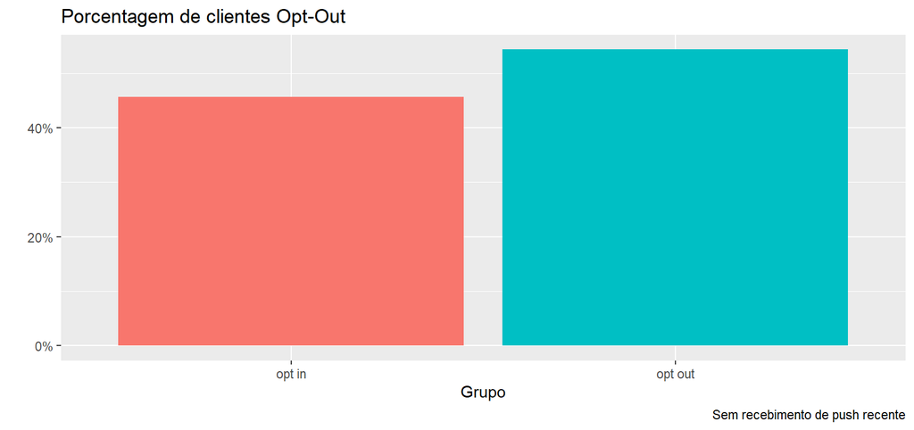

```r
base_d %>%
  group_by(flag_tem_app) %>%
  summarise(contagem = n()) %>%
  mutate(porcentagem = contagem/sum(contagem)) %>%
  ggplot() +
  geom_col(aes(x=flag_tem_app, y=porcentagem, fill=flag_tem_app), show.legend = F)+
  scale_y_continuous(labels = scales::percent_format())+
  labs(title = 'Porcentagem de clientes Opt-Out',
       caption = 'Sem recebimento de push recente',
       x = 'Grupo',
       y = '')
```

```r
queda <- base_d %>%
  #filter(flag_tem_app == 'opt out') %>%
  mutate(mes_ultimo_envio = substring(ultimo_envio,1,7)) %>%
  group_by(mes_ultimo_envio) %>%
  summarise(queda = n()) %>%
  mutate(queda = ifelse(mes_ultimo_envio == '2021-06', 0, queda),
         queda = queda*-1)


total <- as.integer(base_d %>%
  summarise(n()))

base_d2 <- base_d %>%
  mutate(mes_ultimo_envio = '2020-05',
         queda = total) %>%
  select(mes_ultimo_envio, queda) %>%
  unique()

queda <- queda %>%
  union_all(base_d2) %>%
  arrange(mes_ultimo_envio)
```

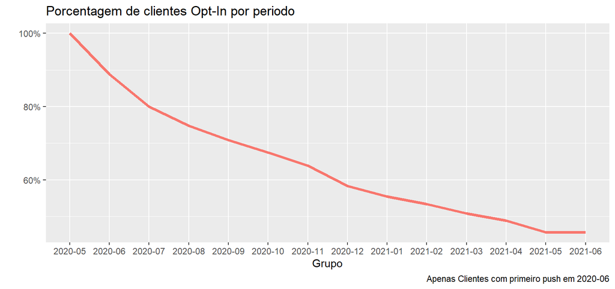

```r
queda <- queda %>%
  transform(Total = ave(queda, FUN = cumsum)) %>%
  mutate(porcentagem = Total/total)


queda %>%
  ggplot() +
  geom_line(aes(x=mes_ultimo_envio, y=porcentagem, group = 1, color = 'x'), show.legend = F, size = 1.4)+
  scale_y_continuous(labels = scales::percent_format())+
  labs(title = 'Porcentagem de clientes Opt-In por periodo',
       caption = 'Apenas Clientes com primeiro push em 2020-06',
       x = 'Grupo',
       y = '')
```

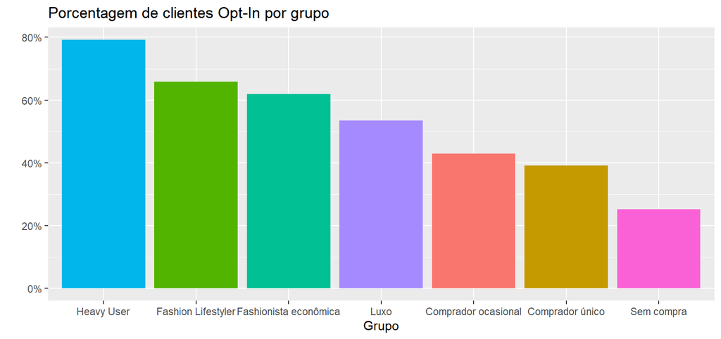

```r
base_d %>%
  group_by(flag_tem_app, grupo) %>%
  summarise(contagem = n()) %>%
  group_by(grupo) %>%
  mutate(porcentagem = contagem/sum(contagem)) %>%
  filter(flag_tem_app == 'opt in') %>%
  ggplot() +
  geom_col(aes(x=reorder(grupo,-porcentagem), y=porcentagem, fill=grupo), show.legend = F)+
  scale_y_continuous(labels = scales::percent_format())+
  labs(title = 'Porcentagem de clientes Opt-In por grupo',
       #caption = 'Apenas Clientes com primeiro push em 2020-06',
       x = 'Grupo',
       y = '')
```

```r
queda <- base_d %>%
  #filter(flag_tem_app == 'opt out') %>%
  mutate(mes_ultimo_envio = substring(ultimo_envio,1,7)) %>%
  group_by(mes_ultimo_envio,grupo) %>%
  summarise(queda = n()) %>%
  mutate(queda = ifelse(mes_ultimo_envio == '2021-06', 0, queda),
         queda = queda*-1)

total <- base_d %>%
  group_by(grupo) %>%
  summarise(contagem = n())

base_d2 <- base_d %>%
  inner_join(total, by = 'grupo') %>%
  mutate(mes_ultimo_envio = '2020-05',
         queda = contagem) %>%
  select(mes_ultimo_envio,grupo, queda) %>%
  unique()

queda <- queda %>%
  union_all(base_d2) %>%
  arrange(mes_ultimo_envio)
```

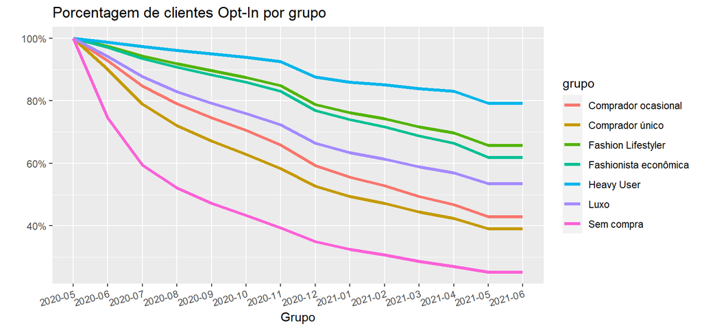

```r
queda <- queda %>%
  transform(Total = ave(queda,grupo, FUN = cumsum))


queda %>%
  group_by(grupo) %>%
  mutate(porcentagem = Total/max(Total)) %>%
  ggplot() +
  geom_line(aes(x=mes_ultimo_envio, y=porcentagem, group = grupo, color = grupo), size = 1.4)+
  #theme(legend.position="bottom")+
  scale_y_continuous(labels = scales::percent_format())+
  labs(title = 'Porcentagem de clientes Opt-In por grupo',
       #caption = 'Queda dia 2021-05-23 (?)',
       x = 'Grupo',
       y = '')+
  theme(axis.text.x = element_text(angle = 15, hjust = 1))
```

### Quantidade de pushes

Se teve mais que 14 envios na primeira semana, deixei 14 só

1 push/dia baixo pq muita gnt nesse grupo só tem 1d (ve e já desinstala)

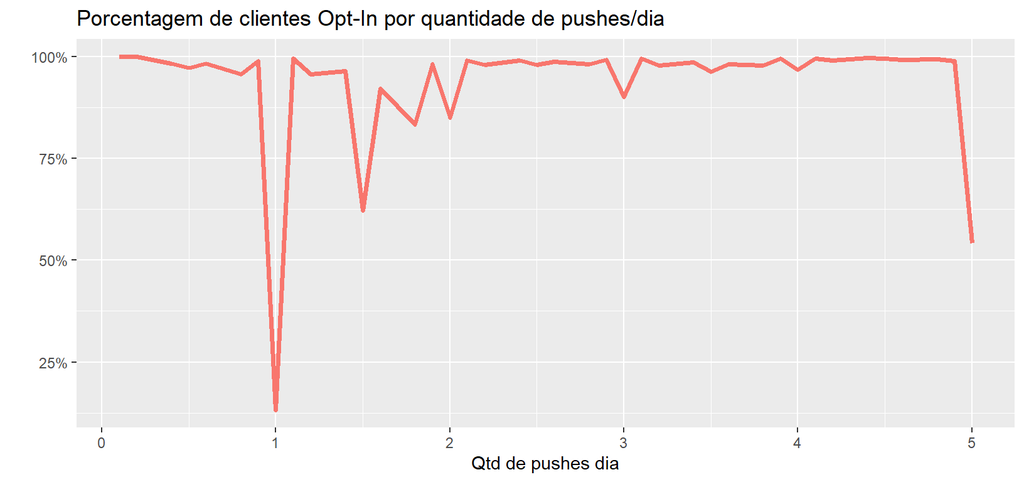

```r
qtd_envios <- base_d %>%
  mutate(qtd_dias = qtd_dias +1,
         flag_mais_1_semana  = ifelse(qtd_dias>7,1,0),
         #flag_mais_1_mes = ifelse(qtd_dias>30,1,0),
         qtd_dias = ifelse(qtd_dias > 7, 8, qtd_dias),
         qtd_envios_dia = qtd_envio_primeira_semana/qtd_dias,
         qtd_envios_dia = round(qtd_envios_dia,1)) %>%
  group_by(qtd_envios_dia,flag_mais_1_semana) %>%
  summarise(contagem = n())  %>%
  arrange(desc(contagem))

qtd_envios %>%
  group_by(qtd_envios_dia) %>%
  mutate(porcentagem = contagem/sum(contagem)) %>%
  arrange(qtd_envios_dia) %>%
  filter(flag_mais_1_semana == 1)%>%
  ggplot() +
  geom_line(aes(x=qtd_envios_dia,y=porcentagem, group=1, color = 'lala'), show.legend = F, size = 1.4)+
  scale_y_continuous(labels = scales::percent_format())+
  labs(title = 'Porcentagem de clientes Opt-In por quantidade de pushes/dia',
       #caption = 'Queda dia 2021-05-23 (?)',
       x = 'Qtd de pushes dia',
       y = '')
```

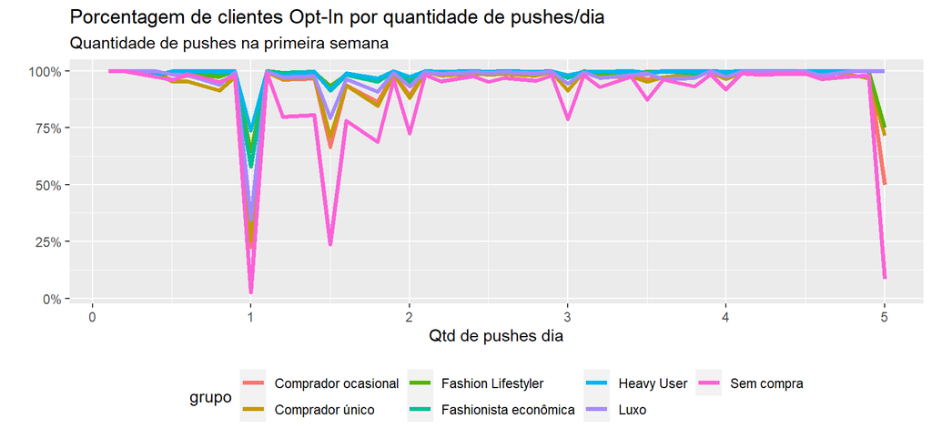

```r
qtd_envios <- base_d %>%
  mutate(qtd_dias = qtd_dias +1,
         flag_mais_1_semana  = ifelse(qtd_dias>7,1,0),
         qtd_dias = ifelse(qtd_dias>7,8,qtd_dias),
         #flag_mais_1_mes = ifelse(qtd_dias>30,1,0),
         qtd_envios_dia = round(qtd_envio_primeira_semana/qtd_dias,1)
         ) %>%
  group_by(qtd_envios_dia,flag_mais_1_semana,grupo) %>%
  summarise(contagem = n())

qtd_envios %>%
  group_by(qtd_envios_dia,flag_mais_1_semana,grupo) %>%
  summarise(contagem = sum(contagem)) %>%
  group_by(qtd_envios_dia,grupo) %>%
  mutate(porcentagem = contagem/sum(contagem)) %>%
  arrange(qtd_envios_dia) %>%
  filter(flag_mais_1_semana == 1) %>%
  ggplot() +
  geom_line(aes(x=qtd_envios_dia,y=porcentagem, color=grupo, group = grupo), size = 1.4) +
  #facet_wrap(grupo~., scales = 'free')+
  scale_y_continuous(labels = scales::percent_format())+
  labs(title = 'Porcentagem de clientes Opt-In por quantidade de pushes/dia',
       subtitle = 'Quantidade de pushes na primeira semana',
       #caption = 'Queda dia 2021-05-23 (?)',
       x = 'Qtd de pushes dia',
       y = '') +
  theme(legend.position="bottom")
```

```r
base_d_aberturas <- read.csv('C:/Users/lucas.general/Documents/Documentos R Markdown/CRM/aberturas.CSV', encoding = "UTF-8")

#base_d_aberturas <- base_d_aberturas %>%
#  rename(pk_customer = X.U.FEFF.pk_customer)
```

20210518 até 20210525

Compra e visita 7d após abertura ou envio

#### Pós Envio

###### Compra Única

```r
aux <- base_d_aberturas %>%
  mutate(flag_aberto = ifelse(qtd_abertos > 0, 1,0)) %>%
  group_by(segment,grupo) %>%
  summarise(qtd_clientes = n(),
            flag_compra_pos_envio = sum(flag_compra_pos_envio)/qtd_clientes,
            visita_pos_envio = sum(visita_pos_envio)/qtd_clientes,
            ) %>%
  mutate(compra_pos_envio = paste0(round(flag_compra_pos_envio*100,2), '%'),
         visita_pos_envio = paste0(round(visita_pos_envio*100,2), '%')) %>%
  select(segment, grupo, qtd_clientes, visita_pos_envio,compra_pos_envio)

aux %>%
  filter(segment == 'Compra_unica') %>%
  knitr::kable(caption = "") %>%
  kable_styling(bootstrap_options = "striped", full_width = T, font_size = 15)
```

| segment | grupo | qtd_clientes | visita_pos_envio | compra_pos_envio |
| --- | --- | --- | --- | --- |
| Compra_unica | 18 ou 19 pushes | 8638 | 36.73% | 1.02% |
| Compra_unica | Dois pushes | 26506 | 40.06% | 1.1% |

###### Compra Ocasional

```r
aux %>%
  filter(segment == 'Comprador_Ocasional') %>%
  knitr::kable(caption = "") %>%
  kable_styling(bootstrap_options = "striped", full_width = T, font_size = 15)
```

| segment | grupo | qtd_clientes | visita_pos_envio | compra_pos_envio |
| --- | --- | --- | --- | --- |
| Comprador_Ocasional | 18 ou 19 pushes | 23227 | 23.83% | 2.09% |
| Comprador_Ocasional | Dois pushes | 72938 | 24.93% | 1.92% |

###### Fashionista Econômica

```r
aux %>%
  filter(segment == 'Fashionista_economica') %>%
  knitr::kable(caption = "") %>%
  kable_styling(bootstrap_options = "striped", full_width = T, font_size = 15)
```

| segment | grupo | qtd_clientes | visita_pos_envio | compra_pos_envio |
| --- | --- | --- | --- | --- |
| Fashionista_economica | 18 ou 19 pushes | 17450 | 46.89% | 6.79% |
| Fashionista_economica | Dois pushes | 62221 | 44.56% | 5.26% |

###### Fashionista LifeStyler

```r
aux %>%
  filter(segment == 'Fashionista_Lifestyler') %>%
  knitr::kable(caption = "") %>%
  kable_styling(bootstrap_options = "striped", full_width = T, font_size = 15)
```

| segment | grupo | qtd_clientes | visita_pos_envio | compra_pos_envio |
| --- | --- | --- | --- | --- |
| Fashionista_Lifestyler | 18 ou 19 pushes | 8119 | 50.63% | 5.86% |
| Fashionista_Lifestyler | Dois pushes | 39751 | 51.11% | 4.78% |

###### Heavy User

```r
aux %>%
  filter(segment == 'Heavy_User') %>%
  knitr::kable(caption = "") %>%
  kable_styling(bootstrap_options = "striped", full_width = T, font_size = 15)
```

| segment | grupo | qtd_clientes | visita_pos_envio | compra_pos_envio |
| --- | --- | --- | --- | --- |
| Heavy_User | 18 ou 19 pushes | 16257 | 37.79% | 3.53% |
| Heavy_User | Dois pushes | 73188 | 35.77% | 2.68% |

###### Luxo

```r
aux %>%
  filter(segment == 'Luxo') %>%
  knitr::kable(caption = "") %>%
  kable_styling(bootstrap_options = "striped", full_width = T, font_size = 15)
```

| segment | grupo | qtd_clientes | visita_pos_envio | compra_pos_envio |
| --- | --- | --- | --- | --- |
| Luxo | 18 ou 19 pushes | 1715 | 35.86% | 3.44% |
| Luxo | Dois pushes | 150 | 41.33% | 7.33% |

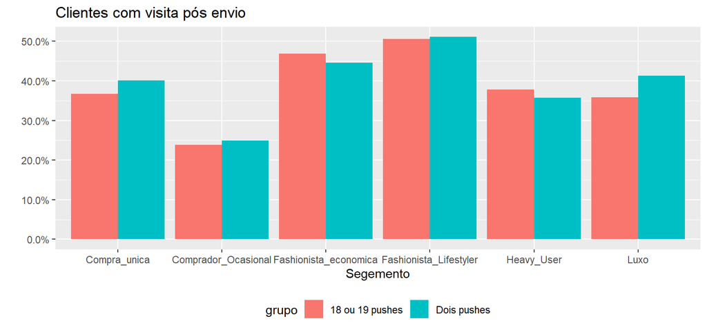

```r
base_d_aberturas %>%
  mutate(flag_aberto = ifelse(qtd_abertos > 0, 1,0)) %>%
  group_by(segment,grupo) %>%
  summarise(qtd_clientes = n(),
            flag_compra_pos_envio = sum(flag_compra_pos_envio)/qtd_clientes,
            visita_pos_envio = sum(visita_pos_envio)/qtd_clientes,
            ) %>%
  ggplot() +
  geom_col(aes(x=segment, y=visita_pos_envio, fill=grupo), position = 'dodge')+
  theme(legend.position="bottom")+
  scale_y_continuous(labels = scales::percent_format())+
  labs(title = 'Clientes com visita pós envio',
       #caption = 'Queda dia 2021-05-23 (?)',
       x = 'Segemento',
       y = '')
```

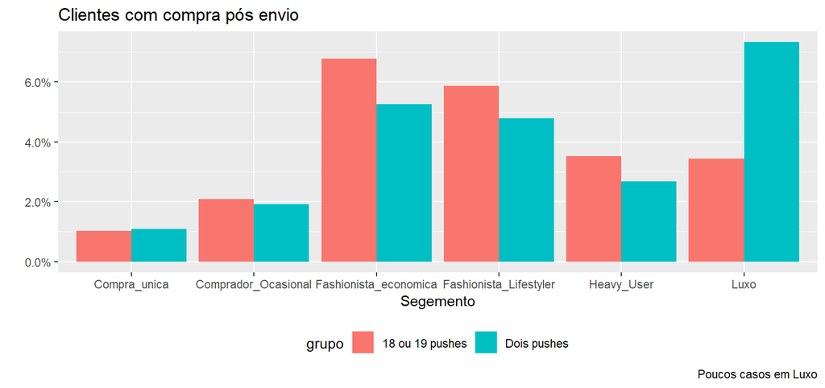

```r
base_d_aberturas %>%
  mutate(flag_aberto = ifelse(qtd_abertos > 0, 1,0)) %>%
  group_by(segment,grupo) %>%
  summarise(qtd_clientes = n(),
            flag_compra_pos_envio = sum(flag_compra_pos_envio)/qtd_clientes,
            visita_pos_envio = sum(visita_pos_envio)/qtd_clientes,
            ) %>%
  ggplot() +
  geom_col(aes(x=segment, y=flag_compra_pos_envio, fill=grupo), position = 'dodge')+
  theme(legend.position="bottom")+
  scale_y_continuous(labels = scales::percent_format())+
  labs(title = 'Clientes com compra pós envio',
       caption = 'Poucos casos em Luxo',
       x = 'Segemento',
       y = '')
```

#### Pós Abertura

###### Compra Única

```r
aux <- base_d_aberturas %>%
  mutate(flag_aberto = ifelse(qtd_abertos > 0, 1,0)) %>%
  group_by(segment,grupo) %>%
  summarise(qtd_clientes = n(),
            qtd_abertura = sum(flag_aberto),
            open_rate = sum(flag_aberto)/qtd_clientes,
            flag_compra_pos_abertura = sum(flag_compra_pos_abertura)/qtd_abertura,
            visita_pos_abertura = sum(visita_pos_abertura)/qtd_abertura
            ) %>%
   mutate(compra_pos_abertura = paste0(round(flag_compra_pos_abertura*100,2), '%'),
         visita_pos_abertura = paste0(round(visita_pos_abertura*100,2), '%'),
         open_rate = paste0(round(open_rate*100,2), '%')) %>%
  select(segment, grupo, qtd_clientes,qtd_abertura,open_rate, visita_pos_abertura,compra_pos_abertura)

aux %>%
  filter(segment == 'Compra_unica') %>%
  knitr::kable(caption = "") %>%
  kable_styling(bootstrap_options = "striped", full_width = T, font_size = 15)
```

| segment | grupo | qtd_clientes | qtd_abertura | open_rate | visita_pos_abertura | compra_pos_abertura |
| --- | --- | --- | --- | --- | --- | --- |
| Compra_unica | 18 ou 19 pushes | 8638 | 575 | 6.66% | 92.87% | 1.91% |
| Compra_unica | Dois pushes | 26506 | 678 | 2.56% | 89.97% | 2.36% |

###### Compra Ocasional

```r
aux %>%
  filter(segment == 'Comprador_Ocasional') %>%
  knitr::kable(caption = "") %>%
  kable_styling(bootstrap_options = "striped", full_width = T, font_size = 15)
```

| segment | grupo | qtd_clientes | qtd_abertura | open_rate | visita_pos_abertura | compra_pos_abertura |
| --- | --- | --- | --- | --- | --- | --- |
| Comprador_Ocasional | 18 ou 19 pushes | 23227 | 1086 | 4.68% | 52.85% | 2.21% |
| Comprador_Ocasional | Dois pushes | 72938 | 1290 | 1.77% | 50.85% | 2.95% |

###### Fashionista Econômica

```r
aux %>%
  filter(segment == 'Fashionista_economica') %>%
  knitr::kable(caption = "") %>%
  kable_styling(bootstrap_options = "striped", full_width = T, font_size = 15)
```

| segment | grupo | qtd_clientes | qtd_abertura | open_rate | visita_pos_abertura | compra_pos_abertura |
| --- | --- | --- | --- | --- | --- | --- |
| Fashionista_economica | 18 ou 19 pushes | 17450 | 1901 | 10.89% | 68.91% | 7.57% |
| Fashionista_economica | Dois pushes | 62221 | 2045 | 3.29% | 68.46% | 7.78% |

###### Fashionista LifeStyler

```r
aux %>%
  filter(segment == 'Fashionista_Lifestyler') %>%
  knitr::kable(caption = "") %>%
  kable_styling(bootstrap_options = "striped", full_width = T, font_size = 15)
```

| segment | grupo | qtd_clientes | qtd_abertura | open_rate | visita_pos_abertura | compra_pos_abertura |
| --- | --- | --- | --- | --- | --- | --- |
| Fashionista_Lifestyler | 18 ou 19 pushes | 8119 | 1054 | 12.98% | 76% | 8.63% |
| Fashionista_Lifestyler | Dois pushes | 39751 | 1858 | 4.67% | 80.03% | 8.29% |

###### Heavy User

```r
aux %>%
  filter(segment == 'Heavy_User') %>%
  knitr::kable(caption = "") %>%
  kable_styling(bootstrap_options = "striped", full_width = T, font_size = 15)
```

| segment | grupo | qtd_clientes | qtd_abertura | open_rate | visita_pos_abertura | compra_pos_abertura |
| --- | --- | --- | --- | --- | --- | --- |
| Heavy_User | 18 ou 19 pushes | 16257 | 1993 | 12.26% | 50.43% | 3.71% |
| Heavy_User | Dois pushes | 73188 | 2481 | 3.39% | 52.2% | 3.71% |

###### Luxo

```r
aux %>%
  filter(segment == 'Luxo') %>%
  knitr::kable(caption = "") %>%
  kable_styling(bootstrap_options = "striped", full_width = T, font_size = 15)
```

| segment | grupo | qtd_clientes | qtd_abertura | open_rate | visita_pos_abertura | compra_pos_abertura |
| --- | --- | --- | --- | --- | --- | --- |
| Luxo | 18 ou 19 pushes | 1715 | 137 | 7.99% | 69.34% | 4.38% |
| Luxo | Dois pushes | 150 | 1 | 0.67% | 100% | 0% |

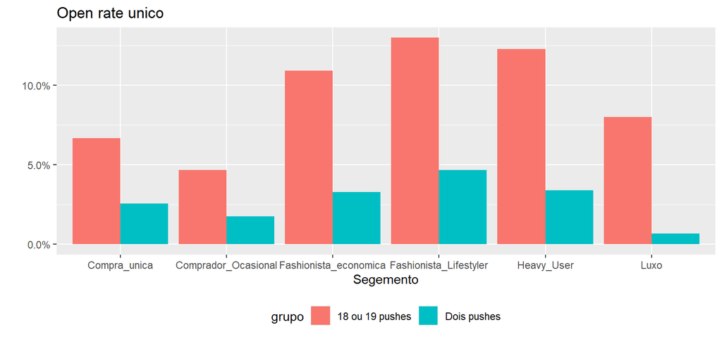

```r
base_d_aberturas %>%
  mutate(flag_aberto = ifelse(qtd_abertos > 0, 1,0)) %>%
  group_by(segment,grupo) %>%
  summarise(qtd_clientes = sum(flag_aberto)/n()
            ) %>%
  ggplot() +
  geom_col(aes(x=segment, y=qtd_clientes, fill=grupo), position = 'dodge')+
  theme(legend.position="bottom")+
  scale_y_continuous(labels = scales::percent_format())+
  labs(title = 'Open rate unico',
       #caption = 'Queda dia 2021-05-23 (?)',
       x = 'Segemento',
       y = '')
```

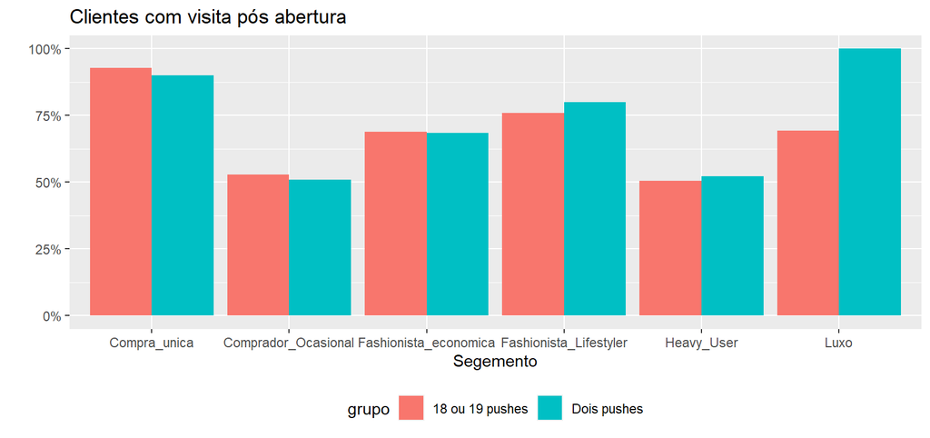

```r
base_d_aberturas %>%
  mutate(flag_aberto = ifelse(qtd_abertos > 0, 1,0)) %>%
  group_by(segment,grupo) %>%
  summarise(qtd_clientes = sum(flag_aberto),
            flag_compra_pos_abertura = sum(flag_compra_pos_abertura)/qtd_clientes,
            visita_pos_abertura = sum(visita_pos_abertura)/qtd_clientes
            ) %>%
  ggplot() +
  geom_col(aes(x=segment, y=visita_pos_abertura, fill=grupo), position = 'dodge')+
  theme(legend.position="bottom")+
  scale_y_continuous(labels = scales::percent_format())+
  labs(title = 'Clientes com visita pós abertura',
       #caption = 'Queda dia 2021-05-23 (?)',
       x = 'Segemento',
       y = '')
```

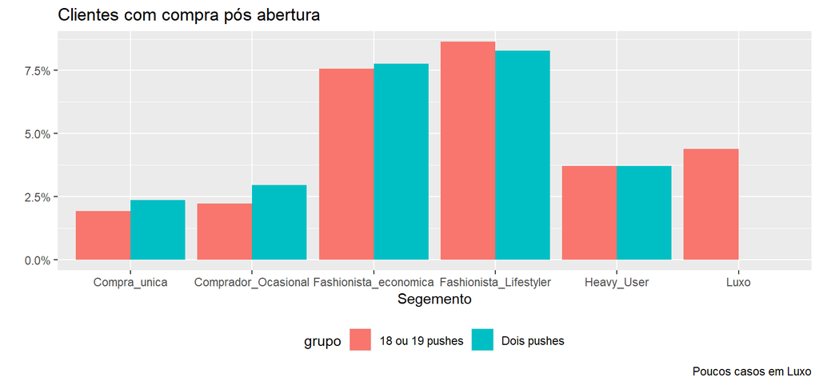

```r
base_d_aberturas %>%
  mutate(flag_aberto = ifelse(qtd_abertos > 0, 1,0)) %>%
  group_by(segment,grupo) %>%
  summarise(qtd_clientes = sum(flag_aberto),
            flag_compra_pos_abertura = sum(flag_compra_pos_abertura)/qtd_clientes,
            visita_pos_abertura = sum(visita_pos_abertura)/qtd_clientes
            ) %>%
  ggplot() +
  geom_col(aes(x=segment, y=flag_compra_pos_abertura, fill=grupo), position = 'dodge')+
  theme(legend.position="bottom")+
  scale_y_continuous(labels = scales::percent_format())+
  labs(title = 'Clientes com compra pós abertura',
       caption = 'Poucos casos em Luxo',
       x = 'Segemento',
       y = '')
```